# Segundo Trabajo TAE

Juan Esteban Restrepo Velez & Sebastian Olarte Jaraba

10/3/2020

#### Universidad Nacional de Colombia sede Medellín

#### Resumen

En este trabajo se abarcan los ejercicios aplicados del texto guía “An Introduction to Statistical Learning with Applications in R” de la materia técnicas de aprendizaje estadístico impartida en la Universidad Nacional de Colombia sede Medellín.

# Capítulo 4.7

## Ejercicio 10

This question should be anwsered using the Weekly data set, which is part of the ISLR package. This data is similar in nature to the Smarket data from this chapter’s lab, except that it contains 1, 089 weekly returns for 21 years, from the beginning of 1990 to the end of 2010.

```r
library(corrplot)
library(psych)
library(MASS)
library(class)
library(Hmisc)
library(PerformanceAnalytics)
library(ggplot2)
library(vcd)
library(GGally)
```

### (a)

Produce some numerical and graphical summaries of the Weekly data. Do there appear to be any patterns?

```r
library(ISLR)
data(Weekly)
attach(Weekly)
rbind(head(Weekly,5), tail(Weekly,5))
```

```
##      Year   Lag1   Lag2   Lag3   Lag4   Lag5    Volume  Today Direction
## 1    1990  0.816  1.572 -3.936 -0.229 -3.484 0.1549760 -0.270      Down
## 2    1990 -0.270  0.816  1.572 -3.936 -0.229 0.1485740 -2.576      Down
## 3    1990 -2.576 -0.270  0.816  1.572 -3.936 0.1598375  3.514        Up
## 4    1990  3.514 -2.576 -0.270  0.816  1.572 0.1616300  0.712        Up
## 5    1990  0.712  3.514 -2.576 -0.270  0.816 0.1537280  1.178        Up
## 1085 2010 -0.861  0.043 -2.173  3.599  0.015 3.2051600  2.969        Up
## 1086 2010  2.969 -0.861  0.043 -2.173  3.599 4.2425680  1.281        Up
## 1087 2010  1.281  2.969 -0.861  0.043 -2.173 4.8350820  0.283        Up
## 1088 2010  0.283  1.281  2.969 -0.861  0.043 4.4540440  1.034        Up
## 1089 2010  1.034  0.283  1.281  2.969 -0.861 2.7071050  0.069        Up
```

```r
summary(Weekly)
```

```
##       Year           Lag1               Lag2               Lag3
##  Min.   :1990   Min.   :-18.1950   Min.   :-18.1950   Min.   :-18.1950
##  1st Qu.:1995   1st Qu.: -1.1540   1st Qu.: -1.1540   1st Qu.: -1.1580
##  Median :2000   Median :  0.2410   Median :  0.2410   Median :  0.2410
##  Mean   :2000   Mean   :  0.1506   Mean   :  0.1511   Mean   :  0.1472
##  3rd Qu.:2005   3rd Qu.:  1.4050   3rd Qu.:  1.4090   3rd Qu.:  1.4090
##  Max.   :2010   Max.   : 12.0260   Max.   : 12.0260   Max.   : 12.0260
##       Lag4               Lag5              Volume            Today
##  Min.   :-18.1950   Min.   :-18.1950   Min.   :0.08747   Min.   :-18.1950
##  1st Qu.: -1.1580   1st Qu.: -1.1660   1st Qu.:0.33202   1st Qu.: -1.1540
##  Median :  0.2380   Median :  0.2340   Median :1.00268   Median :  0.2410
##  Mean   :  0.1458   Mean   :  0.1399   Mean   :1.57462   Mean   :  0.1499
##  3rd Qu.:  1.4090   3rd Qu.:  1.4050   3rd Qu.:2.05373   3rd Qu.:  1.4050
##  Max.   : 12.0260   Max.   : 12.0260   Max.   :9.32821   Max.   : 12.0260
##  Direction
##  Down:484
##  Up  :605
##
##
##
##
```

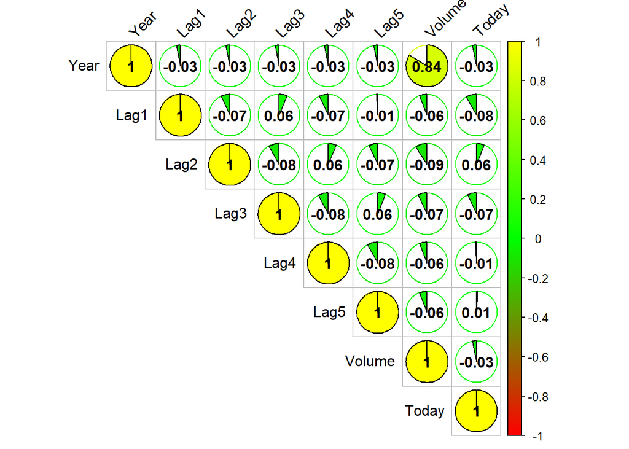

```r
#glimpse(Weekly)
#Se crea la matriz de correlacion
Weekly.corr <- round(cor(Weekly[,-9]),2)
#Weekly.corr
#Se grafica la parte superior de la matriz de correlacion
col <- colorRampPalette(c("red","green","yellow"))
corrplot(Weekly.corr, method = "pie", type = "upper", shade.col = NA,
         tl.col = "black", tl.srt = 45, addCoef.col = "black",
         addshade = "all", col = col(300))
```

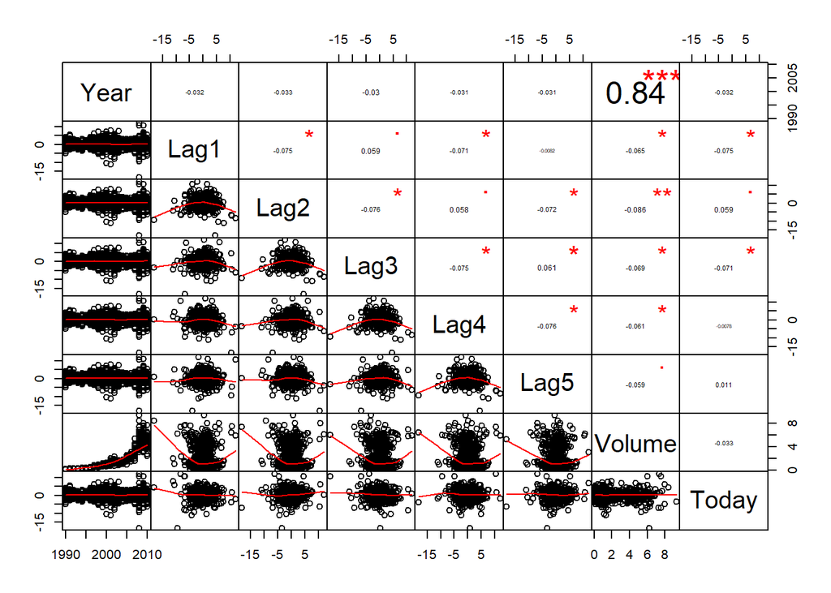

```r
#se hace un diagrama de pares junto con las correlaciones
chart.Correlation(Weekly[,-9], histogram = FALSE, pch = 19)
```

Respuesta: Segun las graficas anteriores, la de la matriz de correlacion y la del grafico de pares con su respectiva correlacion se puede ver que solo las variables año y volumen tienen una alta relacion lineal, dicha relacion es positiva.

### (b)

Use the full data set to perform a logistic regression with Direction as the response and the five lag variables plus Volume as predictors. Use the summary function to print the results. Do any of the predictors appear to be statistically significant? If so, which ones?

```r
logist.fit = glm(Direction ~ Lag1 + Lag2 + Lag3 + Lag4 + Lag5 + Volume, data = Weekly, family = binomial)
summary(logist.fit)
```

```
##
## Call:
## glm(formula = Direction ~ Lag1 + Lag2 + Lag3 + Lag4 + Lag5 +
##     Volume, family = binomial, data = Weekly)
##
## Deviance Residuals:
##     Min       1Q   Median       3Q      Max
## -1.6949  -1.2565   0.9913   1.0849   1.4579
##
## Coefficients:
##             Estimate Std. Error z value Pr(>|z|)
## (Intercept)  0.26686    0.08593   3.106   0.0019 **
## Lag1        -0.04127    0.02641  -1.563   0.1181
## Lag2         0.05844    0.02686   2.175   0.0296 *
## Lag3        -0.01606    0.02666  -0.602   0.5469
## Lag4        -0.02779    0.02646  -1.050   0.2937
## Lag5        -0.01447    0.02638  -0.549   0.5833
## Volume      -0.02274    0.03690  -0.616   0.5377
## ---
## Signif. codes:  0 '***' 0.001 '**' 0.01 '*' 0.05 '.' 0.1 ' ' 1
##
## (Dispersion parameter for binomial family taken to be 1)
##
##     Null deviance: 1496.2  on 1088  degrees of freedom
## Residual deviance: 1486.4  on 1082  degrees of freedom
## AIC: 1500.4
##
## Number of Fisher Scoring iterations: 4
```

Respuesta: Lag2 es el unico predictor con un alto valor significativo. Su p-valor es de 0.0296 < 0.05. Y su valor β2 = 0.05844, este valor positivo lo que indica es que si el valor en el mercado fue positivo hace dos semanas, es más probable que lo sea en el día actual.

### (c)

Compute the confusion matrix and overall fraction of correct predictions. Explain what the confusion matrix is telling you about the types of mistakes made by logistic regression.

```r
logist.probab <- predict(logist.fit, type = "response")
logist.test <- rep("Down", length(logist.probab))
logist.test[logist.probab > 0.5] = "Up"
matriz.confusion <- table(logist.test, Direction)
matriz.confusion
```

```
##            Direction
## logist.test Down  Up
##        Down   54  48
##        Up    430 557
```

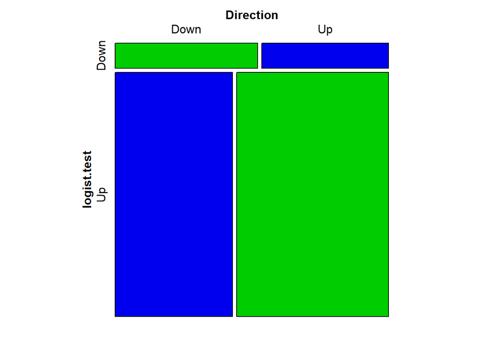

```r
mosaic(matriz.confusion, shade = T, colorize = T,
       gp = gpar(fill = matrix(c("green3", "blue2", "blue2", "green3"), 2, 2)))
```

Respuesta: El porcentaje de predicciones correctas es de: (54 + 557) / (54 + 557 + 48 + 430) = 56.1%. En las semanas en las que el mercado sube, la regresión logística es correcta la mayor parte del tiempo: 557 / (557 + 48) = 92.1% de las boservaciones. En las semanas en las que el mercado baja, la regresión logística ya no es tan precisa solo predice bn el 54 / (430 + 54) = 11.2% de las oservaciones.

### (d)

Now fit the logistic regression model using a training data periodfrom 1990 to 2008, with Lag2 as the only predictor. Compute the confusion matrix and the overall fraction of correct predictions for the held out data (that is, the data from 2009 and 2010).

```r
data.train = (Year < 2009)
data.0910 = Weekly[!data.train, ]

logist.fit = glm(Direction ~ Lag2, data = Weekly, family = binomial, subset = data.train)

logist.probab = predict(logist.fit, data.0910, type = "response")
logist.test = rep("Down", length(logist.probab))
logist.test[logist.probab > 0.5] = "Up"

Direction.0910 = Direction[!data.train]
table(logist.test, Direction.0910)
```

```
##            Direction.0910
## logist.test Down Up
##        Down    9  5
##        Up     34 56
```

```
## [1] "PORCENTAJE DE PREDICCIONES CORRECTAS = 62.5 %"
```

Respuesta: El porcentaje de predicciones correctas es del 62.5%, por lo tanto el test error rate es de 100% - 62.5% = 37.5%. Además, para aquellas semanas con un valor de mercado al alza, el modelo clasifica correctamente el 56/(56+5) = 91,8% de las observaciones; mientras que para las semanas con un valor de mercado a la baja, el modelo acierta en un 9/(9+34) = 20,93% de las veces

### (e)

Repeat (d) using LDA.

```r
lda.fit = lda(Direction ~ Lag2, data = Weekly, subset = data.train)
lda.test = predict(lda.fit, data.0910)
table(lda.test$class, Direction.0910)
```

```
##       Direction.0910
##        Down Up
##   Down    9  5
##   Up     34 56
```

```
## [1] "PORCENTAJE DE PREDICCIONES CORRECTAS = 62.5 %"
```

### (f)

Repeat (d) using QDA.

```r
qda.fit = qda(Direction ~ Lag2, data = Weekly, subset = data.train)
qda.test = predict(qda.fit, data.0910)
table(qda.test$class, Direction.0910)
```

```
##       Direction.0910
##        Down Up
##   Down    0  0
##   Up     43 61
```

```
## [1] "PORCENTAJE DE PREDICCIONES CORRECTAS = 58.7 %"
```

### (g)

Repeat (d) using KNN with K = 1.

```r
train.X = as.matrix(Lag2[data.train])
test.X = as.matrix(Lag2[!data.train])
train.Direction = Direction[data.train]
set.seed(1)
knn.pred = knn(train.X, test.X, train.Direction, k = 1)
table(knn.pred, Direction.0910)
```

```
##         Direction.0910
## knn.pred Down Up
##     Down   21 30
##     Up     22 31
```

```
## [1] "PORCENTAJE DE PREDICCIONES CORRECTAS = 50 %"
```

### (h)

Which of these methods appears to provide the best results on this data?

Respuesta: Los porcentajes de predicciones correctas para cada uno de los modelos es: Regresion Logistica = 62.5% ***** LDA = 62.5% ***** QDA = 58.7% ***** KNN = 50% *** Por lo tanto, los modelos de regresion logistica y LDA son los que mejores resultados arrojan para este conjunto de datos.

### (i)

Experiment with different combinations of predictors, including possible transformations and interactions, for each of the methods. Report the variables, method, and associated confusion matrix that appears to provide the best results on the held out data. Note that you should also experiment with values for K in the KNN classifier.

Para este ejercicio se experimentará con las variables que tienen más peso sobre el modelo de regresion logistica original, las cuales son Lag1 con un valor de β1 = -0.041, Lag2 con β2 = 0.058 y Lag4 con β4 = -0.027.

```
## [1] "REGRESION LOGISTICA CON Lag1 Y Lag2"
```

```r
logist.fit = glm(Direction ~ Lag1 + Lag2, data = Weekly, family = binomial, subset = data.train)
logist.probab = predict(logist.fit, data.0910, type = "response")
logist.test = rep("Down", length(logist.probab))
logist.test[logist.probab > 0.5] = "Up"
Direction.0910 = Direction[!data.train]
#table(logist.test, Direction.0910)
```

```
## [1] "PORCENTAJE DE PREDICCIONES CORRECTAS = 57.692 %"
```

```
## [1] "REGRESION LOGISTICA CON Lag1, Lag2 y Lag4"
```

```r
logist.fit = glm(Direction ~ Lag1 + Lag2 + Lag4, data = Weekly, family = binomial, subset = data.train)
logist.probab = predict(logist.fit, data.0910, type = "response")
logist.test = rep("Down", length(logist.probab))
logist.test[logist.probab > 0.5] = "Up"
Direction.0910 = Direction[!data.train]
#table(logist.test, Direction.0910)
```

```
## [1] "PORCENTAJE DE PREDICCIONES CORRECTAS = 60.577 %"
```

```
## [1] "LDA CON Lag1 y Lag2"
```

```r
lda.fit = lda(Direction ~ Lag2 + Lag1, data = Weekly, subset = data.train)
lda.test = predict(lda.fit, data.0910)
#table(lda.test$class, Direction.0910)
```

```
## [1] "PORCENTAJE DE PREDICCIONES CORRECTAS = 57.692 %"
```

```
## [1] "LDA CON Lag1, Lag2 y Lag4"
```

```r
lda.fit = lda(Direction ~ Lag2 + Lag1 + Lag4, data = Weekly, subset = data.train)
lda.test = predict(lda.fit, data.0910)
#table(lda.test$class, Direction.0910)
```

```
## [1] "PORCENTAJE DE PREDICCIONES CORRECTAS = 60.577 %"
```

```
## [1] "LDA CON INTERACCION ENTRE Lag1 y Lag2"
```

```r
lda.fit = lda(Direction ~ Lag2:Lag1, data = Weekly, subset = data.train)
lda.test = predict(lda.fit, data.0910)
#table(lda.test$class, Direction.0910)
```

```
## [1] "PORCENTAJE DE PREDICCIONES CORRECTAS = 57.692 %"
```

```
## [1] "LDA CON INTERACCION: ENTRE Lag1 Y Lag2, ENTRE Lag2 Y Lag4"
```

```r
lda.fit = lda(Direction ~ Lag2:Lag1 + Lag2:Lag4, data = Weekly, subset = data.train)
lda.test = predict(lda.fit, data.0910)
#table(lda.test$class, Direction.0910)
```

```
## [1] "PORCENTAJE DE PREDICCIONES CORRECTAS = 57.692 %"
```

```
## [1] "QDA CON INTERACCION: ENTRE Lag1 y Lag2, ENTRE Lag2 y Lag4"
```

```r
qda.fit = qda(Direction ~ Lag2:Lag1 + Lag2:Lag4, data = Weekly, subset = data.train)
qda.test = predict(qda.fit, data.0910)$class
#table(qda.test, Direction.0910)
```

```
## [1] "PORCENTAJE DE PREDICCIONES CORRECTAS = 45.192 %"
```

```
## [1] "QDA CON INTERACCION: ENTRE Lag1 y Lag2, ENTRE Lag2 y Lag4, ENTRE Lag1 y Lag4"
```

```r
qda.fit = qda(Direction ~ Lag2:Lag1 + Lag2:Lag4 + Lag1:Lag4, data = Weekly, subset = data.train)
qda.test = predict(qda.fit, data.0910)$class
#table(qda.test, Direction.0910)
```

```
## [1] "PORCENTAJE DE PREDICCIONES CORRECTAS = 59.615 %"
```

```
## [1] "QDA CON Lag2 Y RAIZ DE Lag2"
```

```r
qda.fit = qda(Direction ~ Lag2 + sqrt(abs(Lag2)), data = Weekly, subset = data.train)
qda.test = predict(qda.fit, data.0910)$class
#table(qda.test, Direction.0910)
```

```
## [1] "PORCENTAJE DE PREDICCIONES CORRECTAS = 57.692 %"
```

```
## [1] "QDA CON Lag2 Y RAIZ DE Lag2, Lag1 Y RAIZ DE Lag1"
```

```r
qda.fit = qda(Direction ~ Lag2 + sqrt(abs(Lag2)) + Lag1 + sqrt(abs(Lag1)), data = Weekly, subset = data.train)
qda.test = predict(qda.fit, data.0910)$class
#table(qda.test, Direction.0910)
```

```
## [1] "PORCENTAJE DE PREDICCIONES CORRECTAS = 59.615 %"
```

```
## [1] "KNN CON K=10"
```

```r
knn.pred = knn(train.X, test.X, train.Direction, k = 10)
#table(knn.pred, Direction.0910)
```

```
## [1] "PORCENTAJE DE PREDICCIONES CORRECTAS = 57.692 %"
```

```
## [1] "KNN CON K=50"
```

```r
knn.pred = knn(train.X, test.X, train.Direction, k = 50)
#table(knn.pred, Direction.0910)
```

```
## [1] "PORCENTAJE DE PREDICCIONES CORRECTAS = 56.731 %"
```

```
## [1] "KNN CON K=100"
```

```r
knn.pred = knn(train.X, test.X, train.Direction, k = 100)
#table(knn.pred, Direction.0910)
```

```
## [1] "PORCENTAJE DE PREDICCIONES CORRECTAS = 55.769 %"
```

```
## [1] "KNN CON K=200"
```

```r
knn.pred = knn(train.X, test.X, train.Direction, k = 200)
#table(knn.pred, Direction.0910)
```

```
## [1] "PORCENTAJE DE PREDICCIONES CORRECTAS = 59.615 %"
```

Respuesta: Después de varios experimentos con los diferentes algoritmos y diferentes variables se ve que los que proporcionan mejores resultados son la Regresión Logística inicial y el LDA inicial, ambos usan un solo predictor el cual es Lag2 y presentan la misma test error rate, la cual es de 100% - 62.5% = 37.5%. Los siguientes mejores resultados es la Regresión Logística con los predictores Lag1, Lag2 y Lag4 y el LDA también con los tres predictores Lag1, Lag2 y Lag4, ambos tienen la misma test error rate de 100% - 60.6 % = 39.4%

## Ejercicio 11

In this problem, you will develop a model to predict whether a given car gets high or low gas mileage based on the Auto data set.

```r
library(ISLR)
library(corrplot)
library(psych)
library(MASS)
library(class)
library(Hmisc)
library(PerformanceAnalytics)
library(ggplot2)
library(vcd)
library(GGally)
library(caret)
```

### (a)

Create a binary variable, mpg01, that contains a 1 if mpg contains a value above its median, and a 0 if mpg contains a value below its median. You can compute the median using the median() function. Note you may find it helpful to use the data.frame() function to create a single data set containing both mpg01 and the other Auto variables.

```r
rbind(head(Auto,5), tail(Auto,5))
```

```
##     mpg cylinders displacement horsepower weight acceleration year origin
## 1    18         8          307        130   3504         12.0   70      1
## 2    15         8          350        165   3693         11.5   70      1
## 3    18         8          318        150   3436         11.0   70      1
## 4    16         8          304        150   3433         12.0   70      1
## 5    17         8          302        140   3449         10.5   70      1
## 393  27         4          140         86   2790         15.6   82      1
## 394  44         4           97         52   2130         24.6   82      2
## 395  32         4          135         84   2295         11.6   82      1
## 396  28         4          120         79   2625         18.6   82      1
## 397  31         4          119         82   2720         19.4   82      1
##                          name
## 1   chevrolet chevelle malibu
## 2           buick skylark 320
## 3          plymouth satellite
## 4               amc rebel sst
## 5                 ford torino
## 393           ford mustang gl
## 394                 vw pickup
## 395             dodge rampage
## 396               ford ranger
## 397                chevy s-10
```

```r
summary(Auto)
```

```
##       mpg          cylinders      displacement     horsepower        weight
##  Min.   : 9.00   Min.   :3.000   Min.   : 68.0   Min.   : 46.0   Min.   :1613
##  1st Qu.:17.00   1st Qu.:4.000   1st Qu.:105.0   1st Qu.: 75.0   1st Qu.:2225
##  Median :22.75   Median :4.000   Median :151.0   Median : 93.5   Median :2804
##  Mean   :23.45   Mean   :5.472   Mean   :194.4   Mean   :104.5   Mean   :2978
##  3rd Qu.:29.00   3rd Qu.:8.000   3rd Qu.:275.8   3rd Qu.:126.0   3rd Qu.:3615
##  Max.   :46.60   Max.   :8.000   Max.   :455.0   Max.   :230.0   Max.   :5140
##
##   acceleration        year           origin                      name
##  Min.   : 8.00   Min.   :70.00   Min.   :1.000   amc matador       :  5
##  1st Qu.:13.78   1st Qu.:73.00   1st Qu.:1.000   ford pinto        :  5
##  Median :15.50   Median :76.00   Median :1.000   toyota corolla    :  5
##  Mean   :15.54   Mean   :75.98   Mean   :1.577   amc gremlin       :  4
##  3rd Qu.:17.02   3rd Qu.:79.00   3rd Qu.:2.000   amc hornet        :  4
##  Max.   :24.80   Max.   :82.00   Max.   :3.000   chevrolet chevette:  4
##                                                  (Other)           :365
```

```r
attach(Auto)
mpg01 = rep(0, length(mpg))
mpg01[mpg > median(mpg)] = 1
Auto = data.frame(Auto, mpg01)
rbind(head(Auto,5), tail(Auto,5))
```

```
##     mpg cylinders displacement horsepower weight acceleration year origin
## 1    18         8          307        130   3504         12.0   70      1
## 2    15         8          350        165   3693         11.5   70      1
## 3    18         8          318        150   3436         11.0   70      1
## 4    16         8          304        150   3433         12.0   70      1
## 5    17         8          302        140   3449         10.5   70      1
## 393  27         4          140         86   2790         15.6   82      1
## 394  44         4           97         52   2130         24.6   82      2
## 395  32         4          135         84   2295         11.6   82      1
## 396  28         4          120         79   2625         18.6   82      1
## 397  31         4          119         82   2720         19.4   82      1
##                          name mpg01
## 1   chevrolet chevelle malibu     0
## 2           buick skylark 320     0
## 3          plymouth satellite     0
## 4               amc rebel sst     0
## 5                 ford torino     0
## 393           ford mustang gl     1
## 394                 vw pickup     1
## 395             dodge rampage     1
## 396               ford ranger     1
## 397                chevy s-10     1
```

```r
str(Auto)
```

```
## 'data.frame':    392 obs. of  10 variables:
##  $ mpg         : num  18 15 18 16 17 15 14 14 14 15 ...
##  $ cylinders   : num  8 8 8 8 8 8 8 8 8 8 ...
##  $ displacement: num  307 350 318 304 302 429 454 440 455 390 ...
##  $ horsepower  : num  130 165 150 150 140 198 220 215 225 190 ...
##  $ weight      : num  3504 3693 3436 3433 3449 ...
##  $ acceleration: num  12 11.5 11 12 10.5 10 9 8.5 10 8.5 ...
##  $ year        : num  70 70 70 70 70 70 70 70 70 70 ...
##  $ origin      : num  1 1 1 1 1 1 1 1 1 1 ...
##  $ name        : Factor w/ 304 levels "amc ambassador brougham",..: 49 36 231 14 161 141 54 223 241 2 ...
##  $ mpg01       : num  0 0 0 0 0 0 0 0 0 0 ...
```

### (b)

Explore the data graphically in order to investigate the association between mpg01 and the other features. Which of the other features seem most likely to be useful in predicting mpg01? Scatterplots and boxplots may be useful tools to answer this question. Describe your findings.

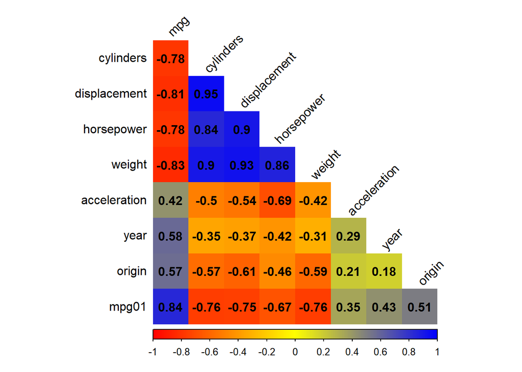

```r
matr.corr <- round(cor(Auto[,-9]),2)
#matr.corr

col <- colorRampPalette(c("red","yellow","blue1"))
corrplot(matr.corr, method = "shade", type = "lower", shade.col = NA,
         tl.col = "black", tl.srt = 45, addCoef.col = "black",
         addshade = "all", col = col(300), diag = FALSE)
```

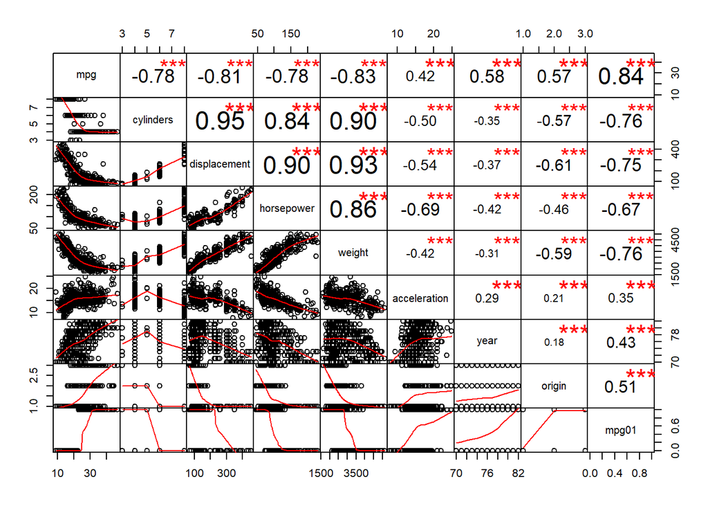

```r
#se hace un diagrama de pares junto con las correlaciones
chart.Correlation(Auto[,-9], histogram = FALSE, pch = 19)
```

Respuesta: Se nota gracias al grafico de la matriz de correlaciones que mpg01 tiene una alta correlacion lineal negativa con las variables cylinders, displacement, horsepower y weight. Además de tener una alta correlacion positiva con la variable mpg por obvias razones.

### (c)

Split the data into a training set and a test set.

```r
set.seed(123)
indice <- createDataPartition(y = Auto$mpg01, p = 0.7, list = FALSE, times = 1)
Auto.train = Auto[indice, ]
Auto.test = Auto[-indice, ]
mpg01.test = mpg01[-indice]
```

### (d)

Perform LDA on the training data in order to predict mpg01 using the variables that seemed most associated with mpg01 in (b). What is the test error of the model obtained?

```r
# LDA
lda.fit = lda(mpg01 ~ cylinders + weight + displacement + horsepower, data = Auto.train)
lda.pred = predict(lda.fit, Auto.test)
prop.correct = mean(lda.pred$class == mpg01.test)
#round(prop.correct,3)
```

```
## [1] "ERROR DE PRUEBA MODELO LDA = 9.5 %"
```

Respuesta: Error de prueba del 9.5%

### (e)

Perform QDA on the training data in order to predict mpg01 using the variables that seemed most associated with mpg01 in (b). What is the test error of the model obtained?

```r
# QDA
qda.fit = qda(mpg01 ~ cylinders + weight + displacement + horsepower, data = Auto.train)
qda.pred = predict(qda.fit, Auto.test)
prop.correct = mean(qda.pred$class == mpg01.test)
#round(prop.correct,3)
```

```
## [1] "ERROR DE PRUEBA MODELO QDA = 9.5 %"
```

Respuesta: Error de prueba del 9.5%

### (f)

Perform logistic regression on the training data in order to predict mpg01 using the variables that seemed most associated with mpg01 in (b). What is the test error of the model obtained?

```r
#REGRESION LOGISTICA
logist.fit = glm(mpg01 ~ cylinders + weight + displacement + horsepower, data = Auto.train,
    family = binomial)
logist.probs = predict(logist.fit, Auto.test, type = "response")
logist.pred = rep(0, length(logist.probs))
logist.pred[logist.probs > 0.5] = 1
prop.correct = mean(logist.pred == mpg01.test)
#round(prop.correct,3)
```

```
## [1] "ERROR DE PRUEBA REGRESION LOGISTICA = 11.2 %"
```

Respuesta: Error de prueba del 11.2%

### (g)

Perform KNN on the training data, with several values of K, in order to predict mpg01. Use only the variables that seemed most associated with mpg01 in (b). What test errors do you obtain? Which value of K seems to perform the best on this data set?

```r
train.X = cbind(cylinders, weight, displacement, horsepower)[indice, ]
test.X = cbind(cylinders, weight, displacement, horsepower)[-indice, ]
train.mpg01 = mpg01[indice]
set.seed(1)
# KNN(k=1)
knn.pred = knn(train.X, test.X, train.mpg01, k = 1)
prop.correct = mean(knn.pred == mpg01.test)
#round(prop.correct,3)
```

```
## [1] "ERROR DE PRUEBA CON KNN (K=1) = 12.1 %"
```

```r
# KNN(k=10)
knn.pred = knn(train.X, test.X, train.mpg01, k = 10)
prop.correct = mean(knn.pred == mpg01.test)
#round(prop.correct,3)
```

```
## [1] "ERROR DE PRUEBA CON KNN (K=10) = 10.3 %"
```

```r
# KNN(k=50)
knn.pred = knn(train.X, test.X, train.mpg01, k = 50)
prop.correct = mean(knn.pred == mpg01.test)
#round(prop.correct,3)
```

```
## [1] "ERROR DE PRUEBA CON KNN (K=50) = 11.2 %"
```

```r
# KNN(k=100)
knn.pred = knn(train.X, test.X, train.mpg01, k = 100)
prop.correct = mean(knn.pred == mpg01.test)
#round(prop.correct,3)
```

```
## [1] "ERROR DE PRUEBA CON KNN (K=100) = 12.1 %"
```

Respuesta: El mejor valor de K para este conjunto de datos es de K=10 ya que nos da el menor error de prueba el cual es de 10.3%

## Ejercicio 12

This problem involves writing functions.

### (a)

Write a function, Power(), that prints out the result of raising 2 to the 3rd power. In other words, your function should compute 23 and print out the results. *Hint: Recall that x^a raises x to the power a. Use the print() function to output the result.*

```r
Power = function() {
    2^3
}
print(Power())
```

```
## [1] 8
```

### (b)

Create a new function, Power2(), that allows you to pass any two numbers, x and a, and prints out the value of x^a. You can do this by beginning your function with the line

```
> Power2 =function (x,a){
```

You should be able to call your function by entering, for instance,

```
> Power2 (3,8)
```

on the command line. This should output the value of 38, namely, 6,561.

```r
Power2 = function(x, a) {
    x^a
}
Power2(3, 3)
```

```
## [1] 27
```

### (c)

Using the Power2() function that you just wrote, compute 10^3, 8^17, and 131^3.

```r
Power2(10, 3)
```

```
## [1] 1000
```

```r
Power2(8, 17)
```

```
## [1] 2.2518e+15
```

```r
Power2(131, 3)
```

```
## [1] 2248091
```

### (d)

Now create a new function, Power3(), that actually returns the result x^a as an R object, rather than simply printing it to the screen. That is, if you store the value x^a in an object called result within your function, then you can simply return() this return() result, using the following line:

return (result )

The line above should be the last line in your function, before the } symbol.

```r
Power3 = function(x, a) {
    result = x^a
    return(result)
}
```

### (e)

Now using the Power3() function, create a plot of f(x) = x2. The x-axis should display a range of integers from 1 to 10, and the y-axis should display x2. Label the axes appropriately, and use an appropriate title for the figure. Consider displaying either the x-axis, the y-axis, or both on the log-scale. You can do this by using log=‘‘x’’, log=‘‘y’’, or log=‘‘xy’’ as arguments to the plot() function.

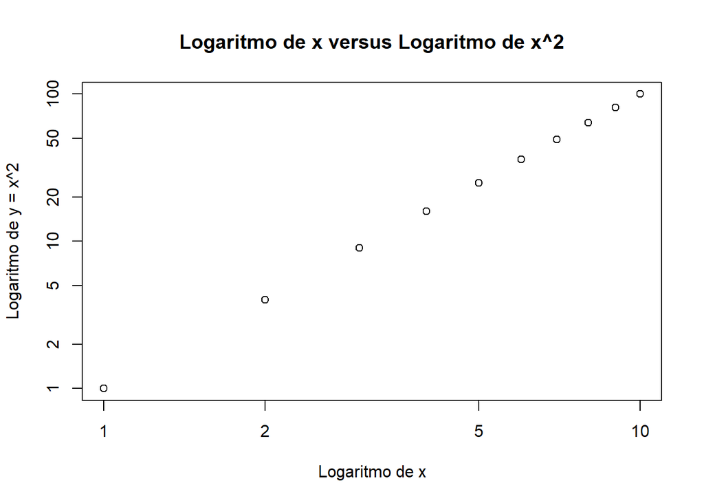

```r
x = 1:10
plot(x, Power3(x, 2), log = "xy", ylab = "Logaritmo de y = x^2", xlab = "Logaritmo de x",
    main = "Logaritmo de x versus Logaritmo de x^2")
```

### (f)

Create a function, PlotPower(), that allows you to create a plot of x against x^a for a fixed a and for a range of values of x. For instance, if you call

> PlotPower (1:10 ,3)

then a plot should be created with an x-axis taking on values 1, 2, . . . , 10, and a y-axis taking on values 13, 23, . . . , 103.

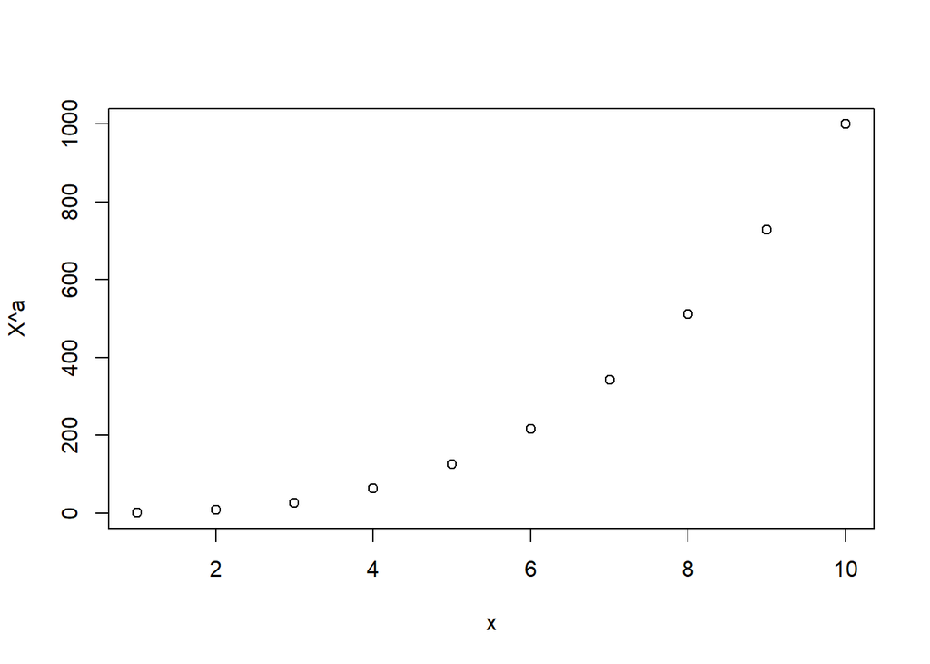

```r
PlotPower = function(x, a) {
    plot(x, Power3(x, a), ylab = "X^a")
}
PlotPower(1:10, 3)
```

## Ejercicio 13

Using the Boston data set, fit classification models in order to predict whether a given suburb has a crime rate above or below the median. Explore logistic regression, LDA, and KNN models using various subsets of the predictors. Describe your findings.

```r
library(ISLR)
library(corrplot)
library(psych)
library(MASS)
library(class)
library(Hmisc)
library(PerformanceAnalytics)
library(ggplot2)
library(vcd)
library(GGally)
library(caret)
```

```r
attach(Boston)
str(Boston)
```

```
## 'data.frame':    506 obs. of  14 variables:
##  $ crim   : num  0.00632 0.02731 0.02729 0.03237 0.06905 ...
##  $ zn     : num  18 0 0 0 0 0 12.5 12.5 12.5 12.5 ...
##  $ indus  : num  2.31 7.07 7.07 2.18 2.18 2.18 7.87 7.87 7.87 7.87 ...
##  $ chas   : int  0 0 0 0 0 0 0 0 0 0 ...
##  $ nox    : num  0.538 0.469 0.469 0.458 0.458 0.458 0.524 0.524 0.524 0.524 ...
##  $ rm     : num  6.58 6.42 7.18 7 7.15 ...
##  $ age    : num  65.2 78.9 61.1 45.8 54.2 58.7 66.6 96.1 100 85.9 ...
##  $ dis    : num  4.09 4.97 4.97 6.06 6.06 ...
##  $ rad    : int  1 2 2 3 3 3 5 5 5 5 ...
##  $ tax    : num  296 242 242 222 222 222 311 311 311 311 ...
##  $ ptratio: num  15.3 17.8 17.8 18.7 18.7 18.7 15.2 15.2 15.2 15.2 ...
##  $ black  : num  397 397 393 395 397 ...
##  $ lstat  : num  4.98 9.14 4.03 2.94 5.33 ...
##  $ medv   : num  24 21.6 34.7 33.4 36.2 28.7 22.9 27.1 16.5 18.9 ...
```

```r
#summary(Boston)
#rbind(head(Boston,5), tail(Boston,5))
crimen.class = rep(0, length(crim))
crimen.class[crim > median(crim)] = 1
Boston = data.frame(Boston, crimen.class)
```

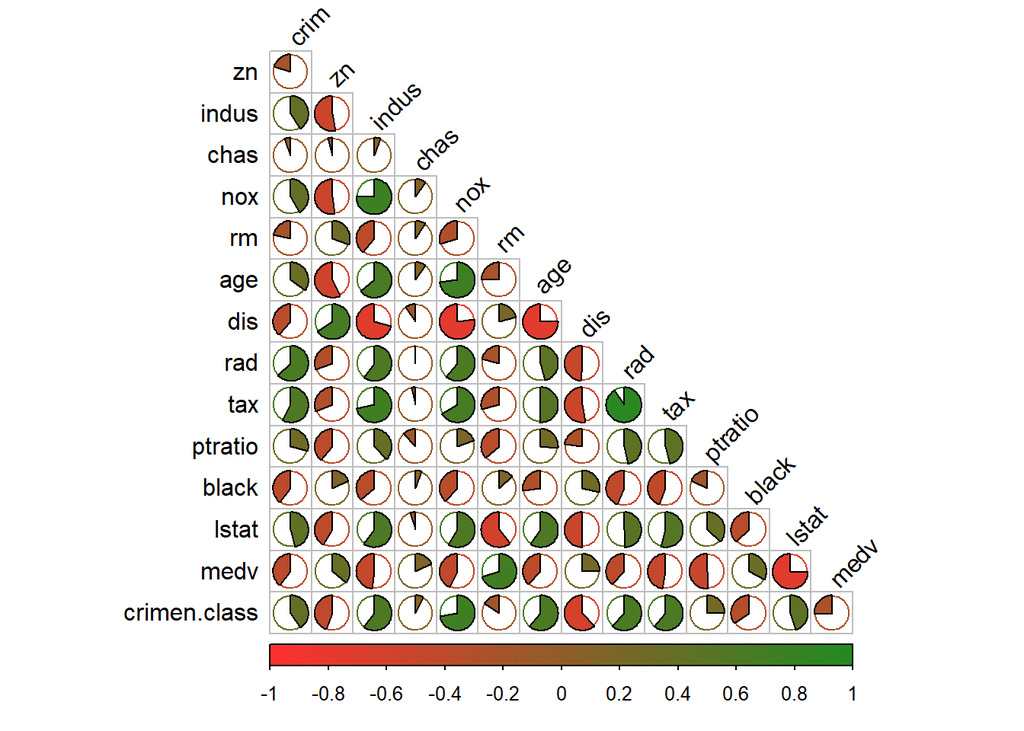

```r
matr.corr <- round(cor(Boston[,]),2)
matr.corr <- round(cor(Boston),2)
#matr.corr
#summary(matr.corr)
col <- colorRampPalette(c("firebrick1","forestgreen"))
corrplot(matr.corr, method = "pie", type = "lower", shade.col = NA,
         tl.col = "black", tl.srt = 45, addshade = "all", col = col(400), diag = FALSE)
```

```r
#Se crean los datos de entreno y de prueba
set.seed(10)
train <- createDataPartition(y = Boston$crimen.class, p = 0.6, list = FALSE, times = 1)
Boston.train = Boston[train, ]
Boston.test = Boston[-train, ]
crimen.class.test = crimen.class[-train]
```

```r
#REGRESION LOGISTICA 1
logist.fit = glm(crimen.class ~ . - crimen.class - crim, data = Boston, subset = train,
                 family = binomial,
    )

logist.probs = predict(logist.fit, Boston.test, type = "response")
logist.pred = rep(0, length(logist.probs))
logist.pred[logist.probs > 0.5] = 1
mean(logist.pred != crimen.class.test)*100
```

```
## [1] 8.910891
```

```r
#REGRESION LOGISTICA 2
logist.fit = glm(crimen.class ~ . -crimen.class -crim -zn -chas -rm -ptratio -black -medv,
                 data = Boston, subset = train, family = binomial)

logist.probs = predict(logist.fit, Boston.test, type = "response")
logist.pred = rep(0, length(logist.probs))
logist.pred[logist.probs > 0.5] = 1
mean(logist.pred != crimen.class.test)*100
```

```
## [1] 10.39604
```

Respuesta: Se crearon dos modelos de regresion logistica. El primero usando todas las variables excepto crimen por obvias razones, este tiene una tasa de error de prueba de 8.91%. El segundo modelo se construyó eliminando algunas variables que tienen muy poca correlacion con la variable dependiente como son *zn*, *chas*, *rm*, *ptratio*, *black* y *medv*, la tasa de error de prueba de este es de 10.4%, por lo cual el primer modelo es mejor predictor.

```r
# LDA 1
lda.fit = lda(crimen.class ~ . -crimen.class -crim, data = Boston, subset = train)
lda.pred = predict(lda.fit, Boston.test)
mean(lda.pred$class != crimen.class.test)*100
```

```
## [1] 15.34653
```

```r
# LDA 2
lda.fit = lda(crimen.class ~ . -crimen.class -crim -zn -chas -rm -ptratio -black -medv,
                 data = Boston, subset = train)
lda.pred = predict(lda.fit, Boston.test)
mean(lda.pred$class != crimen.class.test)*100
```

```
## [1] 14.85149
```

```r
#LDA 3
lda.fit = lda(crimen.class ~ . - crimen.class - crim - chas - tax - lstat - indus - age,
              data = Boston, subset = train)
lda.pred = predict(lda.fit, Boston.test)
mean(lda.pred$class != crimen.class.test)*100
```

```
## [1] 11.38614
```

Respuesta: Se crearon tres modelos de LDA.  
El primero usando todas las variables con tasa de error del 15.35%.  
El segundo excluyendo las variables *zn*, *chas*, *rm*, *ptratio*, *black*, *medv* con tasa de errror del 14.85%.  
El tercero excluyendo las variables *chas*, *tax*, *lstat*, *indus*, *age* con tasa de error del 11.39%.  
Por tanto el mejor modelo predictivo es el **tercero**.

```r
# KNN
train.X = cbind(zn, indus, chas, nox, rm, age, dis, rad, tax, ptratio, black,
                 lstat, medv)[train, ]
test.X = cbind(zn, indus, chas, nox, rm, age, dis, rad, tax, ptratio, black,
                lstat, medv)[-train, ]
train.crimen.class = crimen.class[train]
set.seed(1)

# KNN(k=1)
knn.pred = knn(train.X, test.X, train.crimen.class, k = 1)
mean(knn.pred != crimen.class.test)*100
```

```
## [1] 5.940594
```

```r
# KNN(k=10)
knn.pred = knn(train.X, test.X, train.crimen.class, k = 10)
mean(knn.pred != crimen.class.test)*100
```

```
## [1] 11.38614
```

```r
# KNN(k=100)
knn.pred = knn(train.X, test.X, train.crimen.class, k = 100)
mean(knn.pred != crimen.class.test)*100
```

```
## [1] 23.26733
```

Respuesta: Haciendo las predicciones con todas las variables para KNN con valores de K=1, K=10, K=100, se tienen respectivamente las siguientes tasas de error de prueba: *5.94%*, *11.39%* y *23.27%*. Por lo que el mejor es cuando K=1.

```r
# KNN(k=10) CON UN SUBCONJUNTO DE LAS VARIABLES
train.X = cbind(zn, indus, nox, age, dis, rad, ptratio, black, medv)[train, ]
test.X = cbind(zn, indus, nox, age, dis, rad, ptratio, black, medv)[-train, ]

#(K=1)
knn.pred = knn(train.X, test.X, train.crimen.class, k = 1)
mean(knn.pred != crimen.class.test)*100
```

```
## [1] 13.86139
```

```r
#(K=10)
knn.pred = knn(train.X, test.X, train.crimen.class, k = 10)
mean(knn.pred != crimen.class.test)*100
```

```
## [1] 11.88119
```

# Capítulo 8.4

## Ejercicio 7

In the lab, we applied random forests to the Boston data using mtry=6 and using ntree=25 and ntree=500. Create a plot displaying the test error resulting from random forests on this data set for a more comprehensive range of values for mtry and ntree. You can model your plot after Figure 8.10. Describe the results obtained.

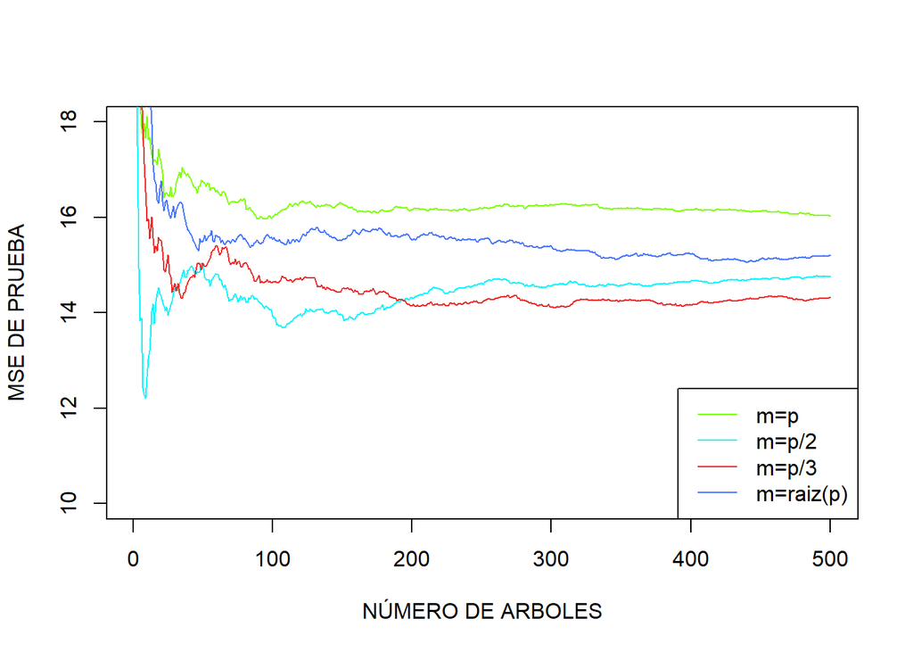

```r
#summary(Boston)
#Crear los subconjuntos de entreno y de prueba
p = ncol(Boston) - 1
p.2 = trunc(p/2)
p.3 = trunc(p/3)
p.raiz = trunc(sqrt(p))

set.seed(100)
train = sample(nrow(Boston), nrow(Boston)/2)
X.train = Boston[train, -14]
X.test = Boston[-train, -14]
Y.train = Boston[train, 14]
Y.test = Boston[-train, 14]

rforest.p = randomForest(X.train, Y.train, xtest = X.test, ytest = Y.test,
    mtry = p, ntree = 500)

rforest.p2 = randomForest(X.train, Y.train, xtest = X.test, ytest = Y.test,
    mtry = p.2, ntree = 500)

rforest.p3 = randomForest(X.train, Y.train, xtest = X.test, ytest = Y.test,
    mtry = p.3, ntree = 500)

rforest.praiz = randomForest(X.train, Y.train, xtest = X.test, ytest = Y.test,
    mtry = p.raiz, ntree = 500)

plot(1:500, rforest.p$test$mse, col = "chartreuse1", type = "l", xlab = "NÚMERO DE ARBOLES",
    ylab = "MSE DE PRUEBA", ylim = c(10, 18))
lines(1:500, rforest.p2$test$mse, col = "turquoise1", type = "l")
lines(1:500, rforest.p3$test$mse, col = "firebrick2", type = "l")
lines(1:500, rforest.praiz$test$mse, col = "royalblue1", type = "l")

legend("bottomright", c("m=p", "m=p/2", "m=p/3", "m=raiz(p)"), col = c("chartreuse1", "turquoise1",    "firebrick2", "royalblue1"),cex = 1, lty = 1)
```

## Ejercicio 8

In the lab, a classification tree was applied to the Carseats data set after converting Sales into a qualitative response variable. Now we will seek to predict Sales using regression trees and related approaches, treating the response as a quantitative variable.

### (a)

Split the data set into a training set and a test set.

```r
library(ISLR)
attach(Carseats)
set.seed(100)
train = sample(nrow(Carseats), nrow(Carseats)/2)
Carseats.train = Carseats[train, ]
Carseats.test = Carseats[-train, ]
```

### (b)

Fit a regression tree to the training set. Plot the tree, and interpret the results. What test MSE do you obtain?

```r
library(tree)
tree.carseats = tree(Sales ~ ., data = Carseats.train,  split = "deviance")
summary(tree.carseats)
```

```
##
## Regression tree:
## tree(formula = Sales ~ ., data = Carseats.train, split = "deviance")
## Variables actually used in tree construction:
## [1] "ShelveLoc"   "Price"       "Age"         "CompPrice"   "Advertising"
## [6] "Education"
## Number of terminal nodes:  17
## Residual mean deviance:  1.844 = 337.5 / 183
## Distribution of residuals:
##     Min.  1st Qu.   Median     Mean  3rd Qu.     Max.
## -3.81700 -0.89580 -0.01857  0.00000  0.92000  2.91800
```

```r
#tree.carseats
```

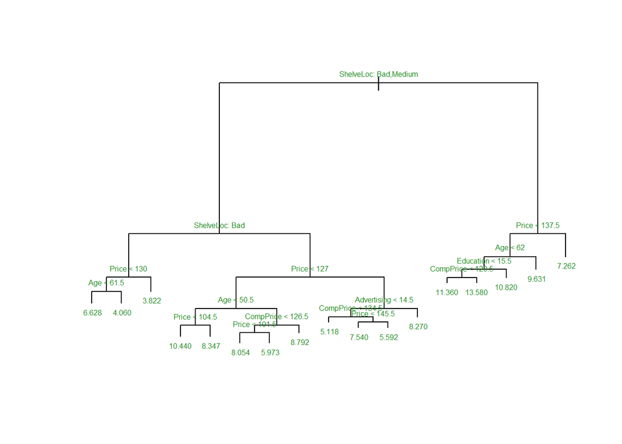

```r
plot(x = tree.carseats, type = "proportional")
text(x = tree.carseats, splits = TRUE, pretty = 0,cex = 0.5, col = "forestgreen")
```

```r
carseats.predict = predict(tree.carseats, newdata = Carseats.test)
mean((carseats.predict - Carseats.test$Sales)^2)
```

```
## [1] 5.395751
```

Analizando la representación del árbol, el predictor más influyente sobre las ventas es el lugar que ocupa el producto en los estantes de las tiendas (ShelveLoc). Este hecho queda reflejado en la primera división del árbol, que separa las posiciones buenas (nodo derecho) de las malas e intermedias (nodo izquierdo).El total de nodos terminales es de 17 y el MSE de error es de alrededor de 5.4

### (c)

Use cross-validation in order to determine the optimal level of tree complexity. Does pruning the tree improve the test MSE?

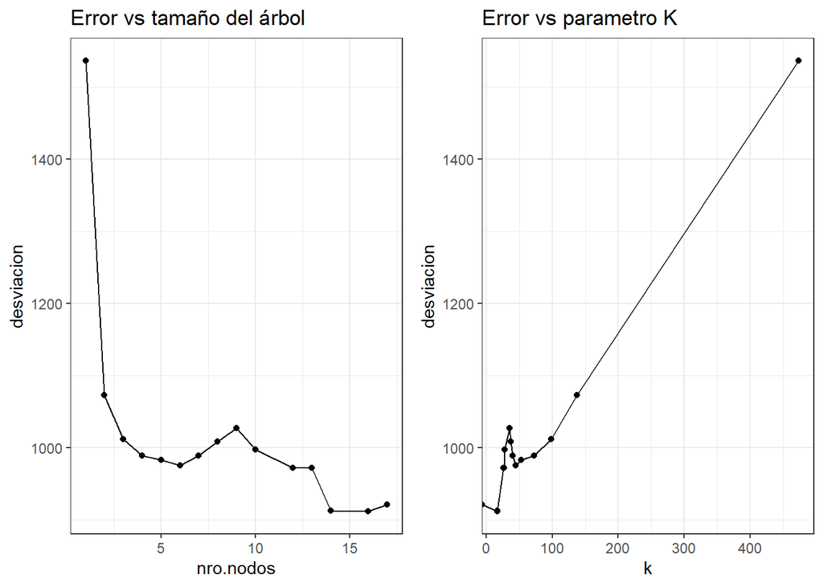

```r
library(ggplot2)
library(ggpubr)
cv.carseats = cv.tree(tree.carseats, FUN = prune.tree)

resultados.cv = data.frame(nro.nodos = cv.carseats$size, desviacion = cv.carseats$dev,
                            k = cv.carseats$k)

p1 = ggplot(data = resultados.cv, aes(x = nro.nodos, y = desviacion)) +
      geom_line() + geom_point() + labs(title = "Error vs tamaño del árbol") + theme_bw()

p2 = ggplot(data = resultados.cv, aes(x = k, y = desviacion)) +
      geom_line() + geom_point() + labs(title = "Error vs parametro K") + theme_bw()

ggarrange(p1, p2)
```

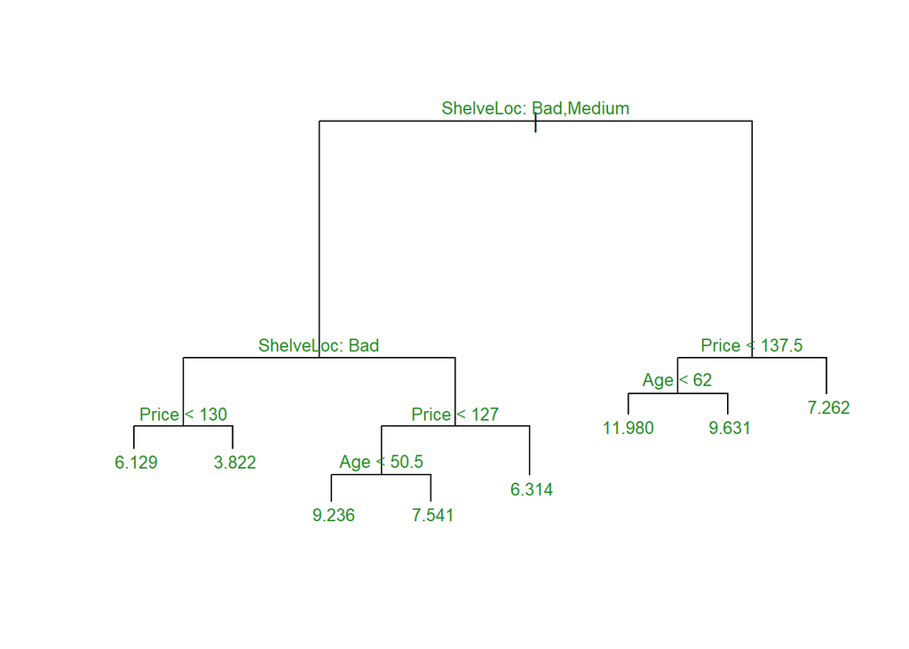

```r
carseats.pruning = prune.tree(tree.carseats, best = 8)
plot(x = carseats.pruning, type = "proportional")
text(x = carseats.pruning, splits = TRUE, pretty = 0, cex = 0.8, col = "forestgreen")
```

```r
carseats.pruning.predict = predict(carseats.pruning, Carseats.test)
round(mean((Carseats.test$Sales - carseats.pruning.predict)^2),2)
```

```
## [1] 5.33
```

### (d)

Use the bagging approach in order to analyze this data. What test MSE do you obtain? Use the importance() function to determine which variables are most important.

```r
library(randomForest)
library(tidyverse)

carseats.bagg = randomForest(Sales ~ ., data = Carseats.train, mtry = 10, ntree = 500,importance = T)
#carseats.bagg
prediccion = predict(carseats.bagg, newdata = Carseats.test)
error = round(mean((Carseats.test$Sales - prediccion)^2),2)
paste("el Error de test (mse) del modelo obtenido por bagging es:", error)
```

```
## [1] "el Error de test (mse) del modelo obtenido por bagging es: 3.23"
```

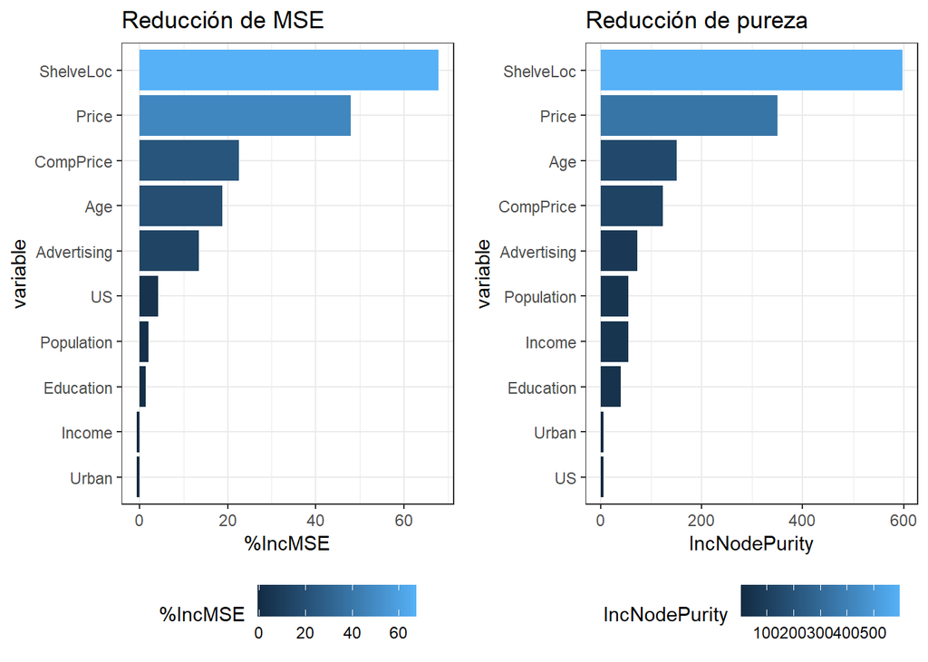

```r
importancia_pred <- as.data.frame(importance(carseats.bagg, scale = TRUE))
importancia_pred <- rownames_to_column(importancia_pred, var = "variable")


p1 <- ggplot(data = importancia_pred, aes(x = reorder(variable, `%IncMSE`), y = `%IncMSE`, fill = `%IncMSE`)) +
    labs(x = "variable", title = "Reducción de MSE") +
    geom_col() +
    coord_flip() +
    theme_bw() +
    theme(legend.position = "bottom")

p2 <- ggplot(data = importancia_pred, aes(x = reorder(variable, IncNodePurity), y = IncNodePurity,
                                          fill = IncNodePurity)) +
    labs(x = "variable", title = "Reducción de pureza") +
    geom_col() +
    coord_flip() +
    theme_bw() +
    theme(legend.position = "bottom")
ggarrange(p1, p2)
```

### (e)

Use random forests to analyze this data. What test MSE do you obtain? Use the importance() function to determine which variables aremost important. Describe the effect of m, the number of variables considered at each split, on the error rate obtained.

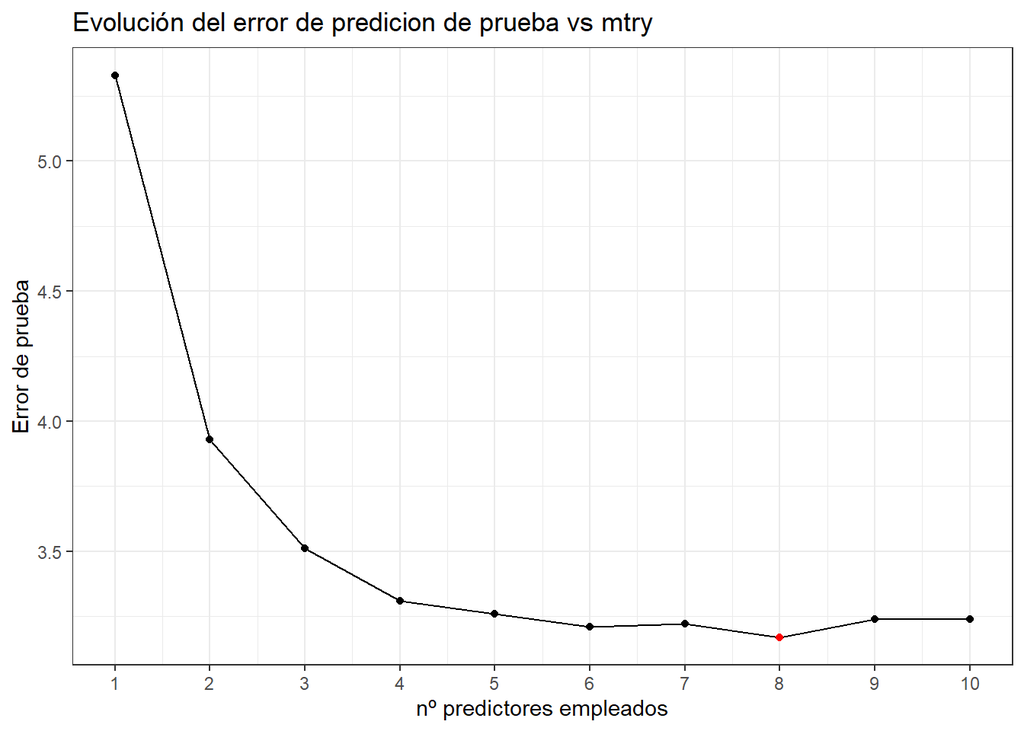

```r
#Random Forest variando los predictores
max.predictores = ncol(Carseats)-1
nro.predictores = rep(NA, max.predictores)
test.error =  rep(NA, max.predictores)

for(i in 1:10){
  carseats.rf = randomForest(Sales ~ ., data = Carseats.train, mtry = i, ntree = 500, importance = T)
  prediccion = predict(carseats.rf, Carseats.test)
  nro.predictores[i] = i
  test.error[i] = round(mean((Carseats.test$Sales - prediccion)^2),2)
  #error = round(mean((Carseats.test$Sales - prediccion)^2),2)
  #mensaje = paste("Error de prueba con ", i, " predictores = ", error)
  #print(mensaje)
}

result.modelos = data.frame(nro.predictores, test.error)

ggplot(data = result.modelos, aes(x = nro.predictores, y = test.error)) +
  scale_x_continuous(breaks = result.modelos$nro.predictores) +
  geom_line() + geom_point() +
  geom_point(data = result.modelos %>% arrange(test.error) %>% head(1), color = "red") +
  labs(title = "Evolución del error de predicion de prueba vs mtry",x = "nº predictores empleados", y = "Error de prueba")+   theme_bw()
```

Variando el valor del numero de predictores m desde 1 hasta 10, el error de prueba disminuye significativamente hasta m=5, de ahi en adelante no se presentan grandes disminuciones, tanto así que cada vez que se corre el algoritmo se obtiene un valor diferente de m entre 5 y 9 que minimiza el error, es decir, a veces el minimo es 5, otras es 6, otras 7, otras 8 y otras incluso es 9, esto se explica gracias a que en cada corrida el algorimto usa combinaciones de predictores diferentes. Un buen valor para usar en nuestro modelo de Random Forest podria ser entonces m = 6.

```r
carseats.r6 = randomForest(Sales ~ ., data = Carseats.train, mtry = 6, ntree = 500, importance = T)
prediccion = predict(carseats.r6, Carseats.test)
error = round(mean((Carseats.test$Sales - prediccion)^2),2)
paste("Error de prueba con 6 predictores = ", error)
```

```
## [1] "Error de prueba con 6 predictores =  3.14"
```

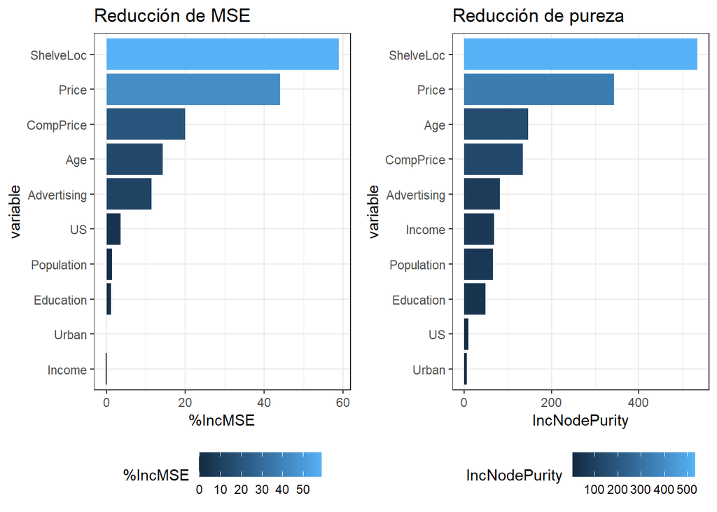

```r
importancia_pred <- as.data.frame(importance(carseats.r6, scale = TRUE))
importancia_pred <- rownames_to_column(importancia_pred, var = "variable")

p1 <- ggplot(data = importancia_pred, aes(x = reorder(variable, `%IncMSE`), y = `%IncMSE`, fill = `%IncMSE`)) +
    labs(x = "variable", title = "Reducción de MSE") +
    geom_col() +
    coord_flip() +
    theme_bw() +
    theme(legend.position = "bottom")

p2 <- ggplot(data = importancia_pred, aes(x = reorder(variable, IncNodePurity), y = IncNodePurity,
                                          fill = IncNodePurity)) +
    labs(x = "variable", title = "Reducción de pureza") +
    geom_col() +
    coord_flip() +
    theme_bw() +
    theme(legend.position = "bottom")
ggarrange(p1, p2)
```

Nuevamente las variables mas importantes en nuestro modelo son **ShelveLoc** y **Price** respectivamente.

## Ejercicio 9

This problem involves the OJ data set which is part of the ISLR package.

### (a)

Create a training set containing a random sample of 800 observations, and a test set containing the remaining observations.

```r
library(ISLR)
library(tree)
attach(OJ)

#str(OJ)
#summary(OJ)
#rbind(head(OJ,5),tail(OJ,5))

set.seed(1000)
train = sample(nrow(OJ), 800)
OJ.train = OJ[train, ]
OJ.test = OJ[-train, ]
```

### (b)

Fit a tree to the training data, with Purchase as the response and the other variables as predictors. Use the summary() function to produce summary statistics about the tree, and describe the results obtained. What is the training error rate? How many terminal nodes does the tree have?

```r
arbol.oj = tree(Purchase ~ ., data = OJ.train)
summary(arbol.oj)
```

```
##
## Classification tree:
## tree(formula = Purchase ~ ., data = OJ.train)
## Variables actually used in tree construction:
## [1] "LoyalCH"     "PriceDiff"   "SalePriceMM"
## Number of terminal nodes:  8
## Residual mean deviance:  0.7486 = 592.9 / 792
## Misclassification error rate: 0.16 = 128 / 800
```

Se creó un arbol de clasificación con un total de 8 nodos terminales y una tasa de error de clasificación del 16%. Siendo los predictores más importantes la lealtad de marca del consumidor al producto CH **(LoyalCH)**; el precio de venta de MM menos precio de venta de CH **(PriceDiff)** y el precio de venta para MM **(SalePriceMM)**.

### (c)

Type in the name of the tree object in order to get a detailed text output. Pick one of the terminal nodes, and interpret the information displayed.

```r
#arbol.oj
```

Analizando el nodo numero 25 vemos que allí la variable decisoria es **PriceDiff** que es la diferencia entre el precio de venta del jugo de naranja Minute Maid (MM) y el precio de venta del jugo de naranja Citrus Hill (CH). En este nodo caen todas las observacions cuyo PriceDiff sea mayor a -0.35 que son en total 104 observaciones. El error de desviacion de todas las observaciones de este nodo es de 126.70 y la prediccion es que el cliente compró Citrus Hill (CH), siendo esta la clase mayoritaria con un total del 70% de las observaciones, mientras que el restante 30% corresponde a la clase Minute Maid (MM).

### (d)

Create a plot of the tree, and interpret the results.

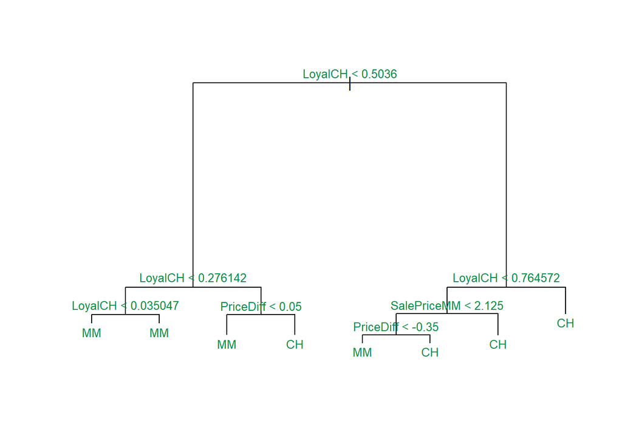

```r
plot(arbol.oj, type = "proportional")
text(arbol.oj, splits = TRUE, pretty = 0, cex = 0.8, col = "springgreen4")
```

Se puede ver como la variable que más peso tiene en el árbol de decisión es **LoyalCH**. Ya que esta variable es el decisor de los nodos más internos, incluso da una clara clasificación para valores extremos: Si **LoyalCH < 0.27** la clasificación es indiscutiblemente **MM** y si **LoyalCH > 0.76** entonces la clasificación es **CH**. Para valores de **LoyalCH** entre **[0.27 ; 0.76]** la decisión ya depende también de *SalePriceMM* y de *PriceDiff*.

### (e)

Predict the response on the test data, and produce a confusion matrix comparing the test labels to the predicted test labels. What is the test error rate?

```r
library("caret")
predicc.oj = predict(arbol.oj, OJ.test, type = "class")
confusionMatrix(predicc.oj, OJ.test$Purchase)
```

```
## Confusion Matrix and Statistics
##
##           Reference
## Prediction  CH  MM
##         CH 150  38
##         MM  11  71
##
##                Accuracy : 0.8185
##                  95% CI : (0.7673, 0.8626)
##     No Information Rate : 0.5963
##     P-Value [Acc > NIR] : 3.798e-15
##
##                   Kappa : 0.6073
##
##  Mcnemar's Test P-Value : 0.0002038
##
##             Sensitivity : 0.9317
##             Specificity : 0.6514
##          Pos Pred Value : 0.7979
##          Neg Pred Value : 0.8659
##              Prevalence : 0.5963
##          Detection Rate : 0.5556
##    Detection Prevalence : 0.6963
##       Balanced Accuracy : 0.7915
##
##        'Positive' Class : CH
##
```

Según la matriz de confusión el porcentaje de precisión es del 81.8% por lo que la tasa del error de prueba es del 18.2%

### (f)

Apply the cv.tree() function to the training set in order to determine the optimal tree size.

```r
set.seed(356)
cv.arbol.oj = cv.tree(arbol.oj, FUN = prune.misclass)
```

### (g)

Produce a plot with tree size on the x-axis and cross-validated classification error rate on the y-axis.

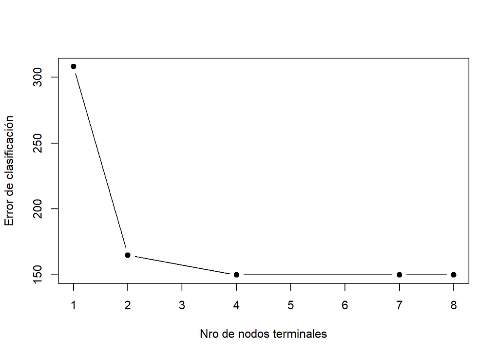

```r
plot(cv.arbol.oj$size, cv.arbol.oj$dev, xlab = "Nro de nodos terminales",
     ylab = "Error de clasificación", type = "b", pch = 19)
```

### (h)

Which tree size corresponds to the lowest cross-validated classification error rate?

### (i)

Produce a pruned tree corresponding to the optimal tree size obtained using cross-validation. If cross-validation does not lead to selection of a pruned tree, then create a pruned tree with five terminal nodes.

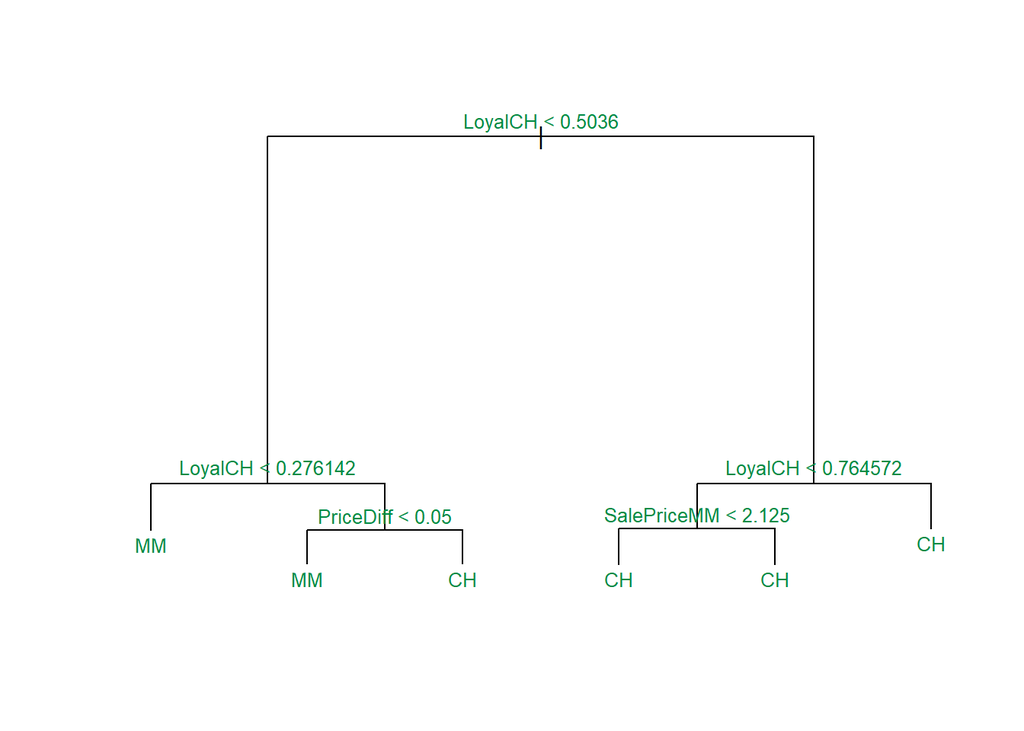

```r
arbol.podado.oj = prune.tree(arbol.oj, best = 6)
plot(arbol.podado.oj, type = "proportional")
text(arbol.podado.oj, splits = TRUE, pretty = 0, cex = 0.8, col = "springgreen4")
```

### (j)

Compare the training error rates between the pruned and unpruned trees. Which is higher?

```r
summary(arbol.oj)
```

```
##
## Classification tree:
## tree(formula = Purchase ~ ., data = OJ.train)
## Variables actually used in tree construction:
## [1] "LoyalCH"     "PriceDiff"   "SalePriceMM"
## Number of terminal nodes:  8
## Residual mean deviance:  0.7486 = 592.9 / 792
## Misclassification error rate: 0.16 = 128 / 800
```

```r
summary(arbol.podado.oj)
```

```
##
## Classification tree:
## snip.tree(tree = arbol.oj, nodes = c(12L, 4L))
## Variables actually used in tree construction:
## [1] "LoyalCH"     "PriceDiff"   "SalePriceMM"
## Number of terminal nodes:  6
## Residual mean deviance:  0.7773 = 617.2 / 794
## Misclassification error rate: 0.17 = 136 / 800
```

La tasa de clasificación errónea del árbol podado es un 1% mayor que la del árbol original, la tasa del original es del 16% mientras que la del árbol podado es del 17%. El error de desviación media también es menor en el árbol original es de 0.7486 mientras que la del árbol podado es de 0.7773.

### (k)

Compare the test error rates between the pruned and unpruned trees. Which is higher?

```r
predicc.arbol.oj = predict(arbol.oj, newdata = OJ.test, type = "class")
erroneos.sinpodar = sum(OJ.test$Purchase != predicc.arbol.oj)
round(erroneos.sinpodar/length(predicc.arbol.oj),2)
```

```
## [1] 0.18
```

```r
predicc.arbol.podado.oj = predict(arbol.podado.oj, newdata = OJ.test, type = "class")
erroneos.podado = sum(OJ.test$Purchase != predicc.arbol.podado.oj)
round(erroneos.podado/length(predicc.arbol.podado.oj),2)
```

```
## [1] 0.2
```

La tasa de error de clasificacion del árbol podado (20%) es mayor que la del árbol sin podar (18%)

## Ejercicio 10

We now use boosting to predict Salary in the Hitters data set.

### (a)

Remove the observations for whom the salary information is unknown, and then log-transform the salaries.

```r
library(ISLR)
sum(is.na(Hitters$Salary))
```

```
## [1] 59
```

```r
Hitters = Hitters[-which(is.na(Hitters$Salary)), ]
sum(is.na(Hitters$Salary))
```

```
## [1] 0
```

```r
Hitters$Salary = log(Hitters$Salary)
```

### (b)

Create a training set consisting of the first 200 observations, and a test set consisting of the remaining observations.

```r
train = 1:200
Hitters.train = Hitters[train, ]
Hitters.test = Hitters[-train, ]
```

### (c)

Perform boosting on the training set with 1,000 trees for a range of values of the shrinkage parameter λ. Produce a plot with different shrinkage values on the x-axis and the corresponding training set MSE on the y-axis.

```r
library(gbm)
```

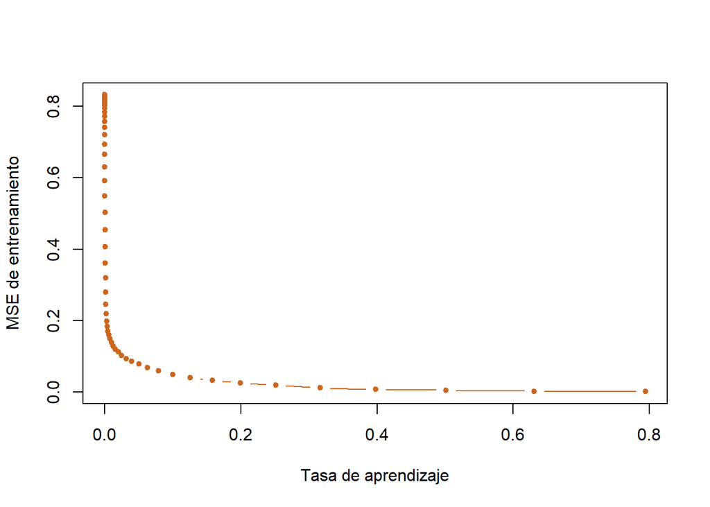

```r
set.seed(103)
learning.rate = 10 ^ seq(-10, -0.1, by = 0.1)
#plot(seq(-10, -0.1, by = 0.1),learning.rate, type = "l")

learning.rate.length = length(learning.rate)
train.errors = rep(NA, learning.rate.length)
test.errors = rep(NA, learning.rate.length)

for (i in 1:learning.rate.length) {
    hitters.boosting = gbm(Salary ~ ., data = Hitters.train, distribution = "gaussian",
                            n.trees = 1000, shrinkage = learning.rate[i])

    train.pred = predict(hitters.boosting, Hitters.train, n.trees = 1000)
    test.pred = predict(hitters.boosting, Hitters.test, n.trees = 1000)

    train.errors[i] = mean((Hitters.train$Salary - train.pred)^2)
    test.errors[i] = mean((Hitters.test$Salary - test.pred)^2)
}

plot(learning.rate, train.errors, type = "b", xlab = "Tasa de aprendizaje", ylab = "MSE de entrenamiento",
    col = "chocolate3", pch = 20)
```

```r
min(train.errors)
```

```
## [1] 0.001145175
```

```r
which.min(train.errors)
```

```
## [1] 100
```

```r
learning.rate[which.min(train.errors)]
```

```
## [1] 0.7943282
```

### (d)

Produce a plot with different shrinkage values on the x-axis and the corresponding test set MSE on the y-axis.

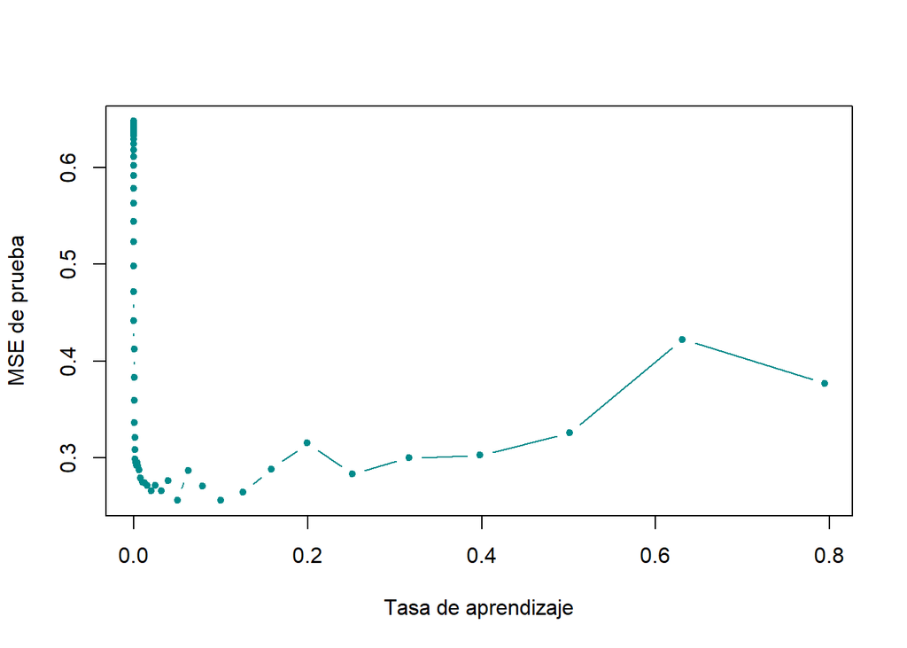

```r
plot(learning.rate, test.errors, type = "b", xlab = "Tasa de aprendizaje", ylab = "MSE de prueba",
    col = "cyan4", pch = 20)
```

```r
min.test.error = round(min(test.errors),5)
paste("EL minimo error de prueba es: ", min.test.error)
```

```
## [1] "EL minimo error de prueba es:  0.25605"
```

```r
min.learning.rate = round(learning.rate[which.min(test.errors)],5)
paste("La tasa de aprendizaje que da un minimo error de prueba es de :", min.learning.rate)
```

```
## [1] "La tasa de aprendizaje que da un minimo error de prueba es de : 0.05012"
```

### (e)

Compare the test MSE of boosting to the test MSE that results from applying two of the regression approaches seen in Chapters 3 and 6.

```r
library(glmnet)
#Usando regresion lineal multiple
lm.fit = lm(Salary ~ ., data = Hitters.train)
lm.pred = predict(lm.fit, Hitters.test)
mse = round(mean((Hitters.test$Salary - lm.pred)^2),5)
paste("el MSE usando un modelo de regresion lineal es de: ", mse)
```

```
## [1] "el MSE usando un modelo de regresion lineal es de:  0.4918"
```

```r
#Usando Ridge Regression y Lasso
set.seed(134)
x = model.matrix(Salary ~ ., data = Hitters.train)
y = Hitters.train$Salary
x.test = model.matrix(Salary ~ ., data = Hitters.test)

#Ridge Regression
ridge.fit = glmnet(x, y, alpha = 0)
ridge.pred = predict(ridge.fit, s = 0.01, newx = x.test)
mse = round(mean((Hitters.test$Salary - ridge.pred)^2),5)
paste("el MSE usando un modelo Ridge Regression es de: ", mse)
```

```
## [1] "el MSE usando un modelo Ridge Regression es de:  0.45703"
```

```r
#Lasso
lasso.fit = glmnet(x, y, alpha = 1)
lasso.pred = predict(lasso.fit, s = 0.01, newx = x.test)
mse = round(mean((Hitters.test$Salary - lasso.pred)^2),5)
paste("el MSE usando un modelo Lasso es de: ", mse)
```

```
## [1] "el MSE usando un modelo Lasso es de:  0.47005"
```

Se observa como el MSE es mucho mayor para modelos de Regresion Lineal, Ridge Regression y Lasso en comparacion con el modelo de Boosting.

### (f)

Which variables appear to be the most important predictors in the boosted model?

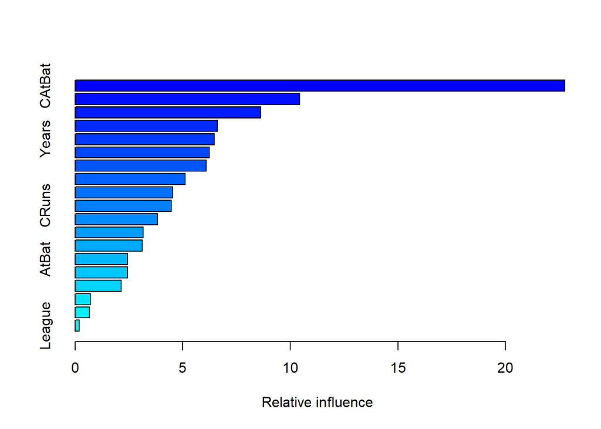

```
##                 var    rel.inf
## CAtBat       CAtBat 22.7562681
## CWalks       CWalks 10.4279674
## CHits         CHits  8.6198109
## PutOuts     PutOuts  6.6159325
## Years         Years  6.4611683
## Walks         Walks  6.2331148
## CRBI           CRBI  6.0926744
## CHmRun       CHmRun  5.1076104
## RBI             RBI  4.5321678
## CRuns         CRuns  4.4728132
## Assists     Assists  3.8366575
## HmRun         HmRun  3.1554038
## Hits           Hits  3.1229284
## AtBat         AtBat  2.4338530
## Errors       Errors  2.4324185
## Runs           Runs  2.1425481
## Division   Division  0.7041949
## NewLeague NewLeague  0.6675446
## League       League  0.1849234
```

```r
mejor.boost = gbm(Salary ~ ., data = Hitters.train, distribution = "gaussian",
                  n.trees = 1000, shrinkage = learning.rate[which.min(test.errors)])
summary(mejor.boost)
```

Las 5 variables de mayor importancia en el modelo son según su importancia: *CAtBat*, *CWalks*, *CHits*, *PutOuts*, *Years*.

### (g)

Now apply bagging to the training set. What is the test set MSE for this approach?

```r
library(randomForest)
set.seed(21)
rf.hitters = randomForest(Salary ~ ., data = Hitters.train, ntree = 500, mtry = 19)
rf.pred = predict(rf.hitters, Hitters.test)
error = round(mean((Hitters.test$Salary - rf.pred)^2),5)
paste("EL MSE de prueba para el modelo bagging es de: ", error)
```

```
## [1] "EL MSE de prueba para el modelo bagging es de:  0.23039"
```

## Ejercicio 11

This question uses the Caravan data set.

### (a)

Create a training set consisting of the first 1,000 observations, and a test set consisting of the remaining observations.

```r
library(ISLR)
library(gbm)
library(class)
#str(Caravan)
#rbind(head(Caravan,5),tail(Caravan,5))

train = 1:1000
Caravan$Purchase = ifelse(Caravan$Purchase == "Yes", 1, 0)
Caravan.train = Caravan[train, ]
Caravan.test = Caravan[-train, ]
```

### (b)

Fit a boosting model to the training set with Purchase as the response and the other variables as predictors. Use 1,000 trees, and a shrinkage value of 0.01. Which predictors appear to be the most important?

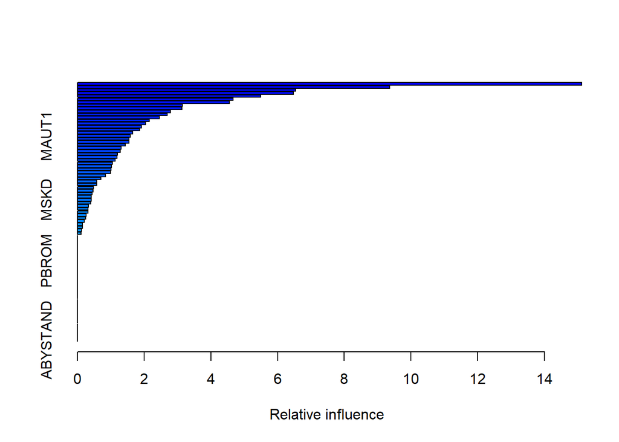

```
##               var    rel.inf
## PPERSAUT PPERSAUT 15.1165280
## MKOOPKLA MKOOPKLA  9.3640996
## MBERMIDD MBERMIDD  6.5432394
## MOPLHOOG MOPLHOOG  6.4805293
## PBRAND     PBRAND  5.4894532
## ABRAND     ABRAND  4.6686620
## MGODGE     MGODGE  4.5524402
## MSKA         MSKA  3.1446372
## MINK3045 MINK3045  3.1422142
## MOSTYPE   MOSTYPE  2.7836516
## MSKC         MSKC  2.6954051
## PWAPART   PWAPART  2.4636809
## MGODPR     MGODPR  2.1497270
## MBERARBG MBERARBG  2.0414137
## MINKGEM   MINKGEM  1.9162324
## PBYSTAND PBYSTAND  1.8661739
## MGODOV     MGODOV  1.6543497
## MAUT1       MAUT1  1.5869355
## MBERHOOG MBERHOOG  1.5512684
## MRELGE     MRELGE  1.5457176
## MSKB1       MSKB1  1.4413468
## MINKM30   MINKM30  1.3080794
## MAUT2       MAUT2  1.2910526
## MFWEKIND MFWEKIND  1.2031714
## MRELOV     MRELOV  1.1950252
## MHKOOP     MHKOOP  1.1387480
## MFGEKIND MFGEKIND  1.0518503
## MOPLMIDD MOPLMIDD  1.0240559
## MINK7512 MINK7512  1.0043686
## MAUT0       MAUT0  0.9977901
## MGODRK     MGODRK  0.8398790
## MHHUUR     MHHUUR  0.7095054
## MINK4575 MINK4575  0.5807071
## MGEMLEEF MGEMLEEF  0.5766080
## MZFONDS   MZFONDS  0.4838370
## MBERBOER MBERBOER  0.4696348
## PMOTSCO   PMOTSCO  0.4459358
## APERSAUT APERSAUT  0.4139543
## MSKD         MSKD  0.4123073
```

[output cut: 31 more lines]

```
## AMOTSCO   AMOTSCO  0.0000000
## AVRAAUT   AVRAAUT  0.0000000
## AAANHANG AAANHANG  0.0000000
## ATRACTOR ATRACTOR  0.0000000
## AWERKT     AWERKT  0.0000000
## ABROM       ABROM  0.0000000
## ALEVEN     ALEVEN  0.0000000
## APERSONG APERSONG  0.0000000
## AGEZONG   AGEZONG  0.0000000
## AWAOREG   AWAOREG  0.0000000
## AZEILPL   AZEILPL  0.0000000
## APLEZIER APLEZIER  0.0000000
## AFIETS     AFIETS  0.0000000
## AINBOED   AINBOED  0.0000000
## ABYSTAND ABYSTAND  0.0000000
```

```r
set.seed(400)
boost.caravan = gbm(Purchase ~ ., data = Caravan.train, n.trees = 1000, shrinkage = 0.01,
                    distribution = "bernoulli")

summary(boost.caravan)
```

Ordenadas segun su importancia las 5 variables mas importantes del modelo son respectivamente: **PPERSAUT**, **MKOOPKLA**, **MBERMIDD**, **MOPLHOOG**, **PBRAND**.

### (c)

Use the boosting model to predict the response on the test data. Predict that a person will make a purchase if the estimated probability of purchase is greater than 20 %. Form a confusion matrix. What fraction of the people predicted to make a purchase do in fact make one? How does this compare with the results obtained from applying KNN or logistic regression to this data set?

```r
boost.prob = predict(boost.caravan, Caravan.test, n.trees = 1000, type = "response")
boost.pred = ifelse(boost.prob > 0.2, 1, 0)
matrix.conf = table(Caravan.test$Purchase, boost.pred)
verdadero.compr = round(matrix.conf[2,2]/sum(matrix.conf[,2]),2)

paste("La fraccion de personas que el modelo predijo como compradores y que efectuaron una compra es de:", verdadero.compr)
```

```
## [1] "La fraccion de personas que el modelo predijo como compradores y que efectuaron una compra es de: 0.23"
```

```r
#Usando Regresión Logistica.
lm.caravan = glm(Purchase ~ ., data = Caravan.train, family = binomial)
lm.prob = predict(lm.caravan, Caravan.test, type = "response")
lm.pred = ifelse(lm.prob > 0.2, 1, 0)

matrix.conf = table(Valor_real = Caravan.test$Purchase, Prediccion = lm.pred)
verdadero.compr = round(matrix.conf[2,2]/sum(matrix.conf[,2]),2)
matrix.conf
```

```
##           Prediccion
## Valor_real    0    1
##          0 4183  350
##          1  231   58
```

```r
verdadero.compr
```

```
## [1] 0.14
```

```r
paste("La fraccion usando Regresión Logistica es:", verdadero.compr)
```

```
## [1] "La fraccion usando Regresión Logistica es: 0.14"
```

```r
#Usando KNN.
nros.k = 1:10
v.fracc = rep(NA,length(nros.k))

for(i in 1:length(nros.k)){
  Knn.predicc = knn(Caravan.train[,1:85], Caravan.test[,1:85], Caravan.train$Purchase, k = i, prob = TRUE )
  matrix.conf = table(Caravan.test$Purchase, Knn.predicc)
  verdadero.compr = round(matrix.conf[2,2]/sum(matrix.conf[,2]),4)
  v.fracc[i] = verdadero.compr
  Knn.predicc = NULL
}
paste("K =", nros.k, "fr =", v.fracc)
```

```
##  [1] "K = 1 fr = 0.0825" "K = 2 fr = 0.1127" "K = 3 fr = 0.1268"
##  [4] "K = 4 fr = 0.122"  "K = 5 fr = 0.1176" "K = 6 fr = 0.1034"
##  [7] "K = 7 fr = 0.1111" "K = 8 fr = 0.1818" "K = 9 fr = 0.25"
## [10] "K = 10 fr = 0"
```

## Ejercicio 12

Apply boosting, bagging, and random forests to a data set of your choice. Be sure to fit the models on a training set and to evaluate their performance on a test set. How accurate are the results compared to simple methods like linear or logistic regression? Which of these approaches yields the best performance?

Para este ejercicio se hará uso del conjunto de datos College de la librería ISLR el cual registra datos en 18 variables de 777 universidades de los estados unidos. La primera de estas variables indica si la universidad es privada o no es privada. Se crearán entonces diferentes modelos de clasificación que permitirán predecir si una universidad es privada o no en función de las otras 17 variables y se evaluarán los rendimientos de estos modelos.

```r
library(ISLR)
library(gbm)
library(randomForest)
library(tidyverse)
#summary(College)
#str(OJ)
set.seed(100)
train = sample(nrow(College), 0.7* nrow(College))
train.college = College[train,]
test.college = College[-train,]
```

MODELO DE REGRESIÓN LOGISTICA

```r
#Probabilidades <= 0.5 corresponderan a universidades no privadas y > 0.5 a universidades privadas
glm.fit = glm(Private ~ ., data = train.college, family = "binomial")
glm.probs = predict(glm.fit, newdata = test.college, type = "response")
glm.pred = rep("No", length(glm.probs))
glm.pred[glm.probs > 0.5] = "Yes"

table(Prediccion = glm.pred, Valor_real = test.college$Private[])
```

```
##           Valor_real
## Prediccion  No Yes
##        No   60   6
##        Yes  10 158
```

```r
porc.acierto = round(mean(glm.pred == test.college$Private)*100,2)
paste("Rendimiento usando Regresion Logistica =", porc.acierto, "%")
```

```
## [1] "Rendimiento usando Regresion Logistica = 93.16 %"
```

MODELO USANDO BOOSTING

```r
#Se crea una nueva variable binaria en función de la variable Private. Para poder usar la distribucion bernoulli en el parametro distribution
College$Private01 = ifelse(College$Private == "Yes", 1, 0)

college.boost = gbm(Private01 ~ ., data = College[train,-1], distribution = "bernoulli", n.trees = 5000)
college.probs = predict(college.boost, newdata = College[-train,-1], n.trees = 5000)
college.predic = rep(0, length(college.probs))
college.predic[college.probs > 0.5] = 1

table(Prediccion = college.predic, Valor_real = College$Private01[-train])
```

```
##           Valor_real
## Prediccion   0   1
##          0  64  13
##          1   6 151
```

```r
porc.acierto = round(mean(college.predic == College$Private01[-train])*100,2)
paste("Rendimiento usando Bossting =", porc.acierto, "%")
```

```
## [1] "Rendimiento usando Bossting = 91.88 %"
```

```r
College = College[,-19]
```

MODELO USANDO BAGGING

```r
college.bagg = randomForest(Private ~ ., data = train.college, mtry = 17)
college.bagg.pred = predict(college.bagg, newdata = test.college)

table(Prediccion = college.bagg.pred, Valor_real = test.college$Private)
```

```
##           Valor_real
## Prediccion  No Yes
##        No   61   5
##        Yes   9 159
```

```r
porc.acierto = round(mean(college.bagg.pred == test.college$Private)*100,2)
paste("Rendimiento usando Bossting =", porc.acierto, "%")
```

```
## [1] "Rendimiento usando Bossting = 94.02 %"
```

MODELO USANDO RANDOM FOREST

```r
college.rf = randomForest(Private ~ ., data = train.college, mtry = 10)
college.rf.pred = predict(college.rf, newdata = test.college)

table(Prediccion = college.rf.pred, test.college$Private)
```

```
##
## Prediccion  No Yes
##        No   63   6
##        Yes   7 158
```

```r
porc.acierto = round(mean(college.rf.pred == test.college$Private)*100,2)
paste("Rendimiento usando Bossting =", porc.acierto, "%")
```

```
## [1] "Rendimiento usando Bossting = 94.44 %"
```

Los metodos con mejor resultado fueron los de **Bagging** y **RandomForest**. Ambos tienen un porcentaje de acierto mayor que el de la Regresion Logistica y el del metodo de Boosting.

# Capítulo 9.7

## Ejercicio 4

Generate a simulated two-class data set with 100 observations and two features in which there is a visible but non-linear separation between the two classes. Show that in this setting, a support vector machine with a polynomial kernel (with degree greater than 1) or a radial kernel will outperform a support vector classifier on the training data. Which technique performs best on the test data? Make plots and report training and test error rates in order to back up your assertions.

```r
library(e1071)
```

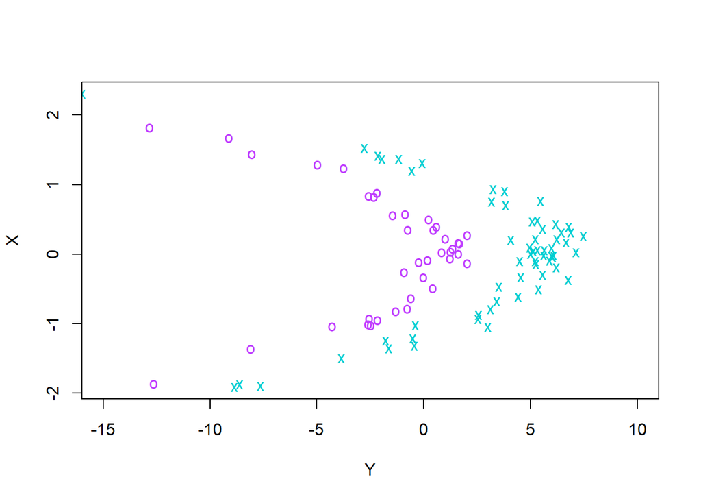

```r
#Se crean los datos X y Y aleatorios
set.seed(200)
x = rnorm(100)
y = 4* -x^2 + 2 + rnorm(100)
#60% serán de la clase +1 y 40% de la clase -1
clasepos = sample(100, 60)
y[clasepos] = y[clasepos] +4
y[-clasepos] = y[-clasepos] -1
z = rep(-1, 100)
z[clasepos] = 1

plot(y[clasepos],x[clasepos], pch="x", lwd=4, col="darkturquoise", xlim=c(-15, 10), xlab="Y", ylab="X")
points(y[-clasepos], x[-clasepos], pch="o", lwd=4, col="darkorchid1")
```

```r
#Se crean las variables respuestas -1 y +1
set.seed(300)
datos = data.frame(x,y,z = as.factor(z))
#70% de los datos se usarán para entreno y 30% para prueba
train = sample(100, 70)
datos.train = datos[train,]
datos.test = datos[-train,]

#verifivar distribucion de las clases en los datos de entreno y de prueba
table(datos.train[,3])
```

```
##
## -1  1
## 27 43
```

```r
table(datos.test[,3])
```

```
##
## -1  1
## 13 17
```

```r
prop.table(table(datos.train[,3]))
```

```
##
##        -1         1
## 0.3857143 0.6142857
```

```r
prop.table(table(datos.test[,3]))
```

```
##
##        -1         1
## 0.4333333 0.5666667
```

KERNEL LINEAL

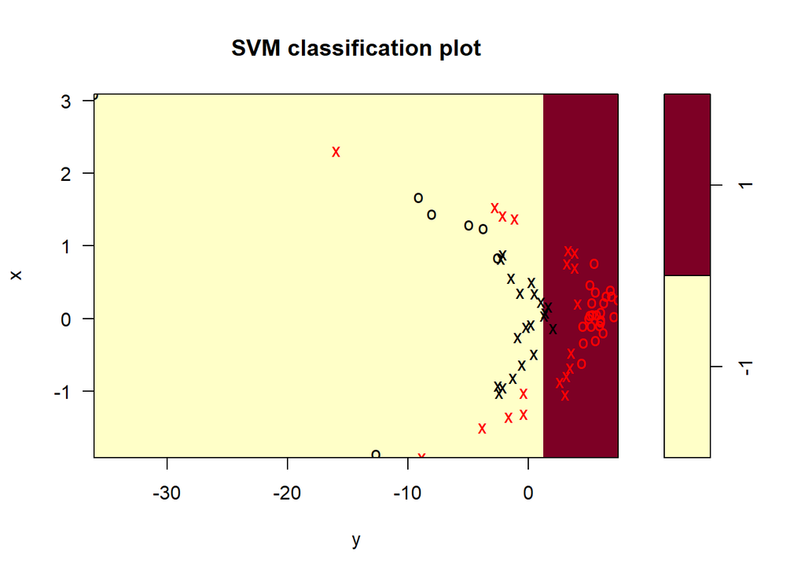

```r
svm.linear = svm(z~., data=datos.train, kernel="linear", cost=10)
plot(svm.linear, datos.train)
```

```r
prediccion = predict(svm.linear, datos.train)
table(prediccion , real = datos.train$z)
```

```
##           real
## prediccion -1  1
##         -1 22  9
##         1   5 34
```

```r
train.error = round(mean(prediccion != datos.train$z)*100,3)

paste("Para un Kernel Lineal el train error es del", train.error, "%")
```

```
## [1] "Para un Kernel Lineal el train error es del 20 %"
```

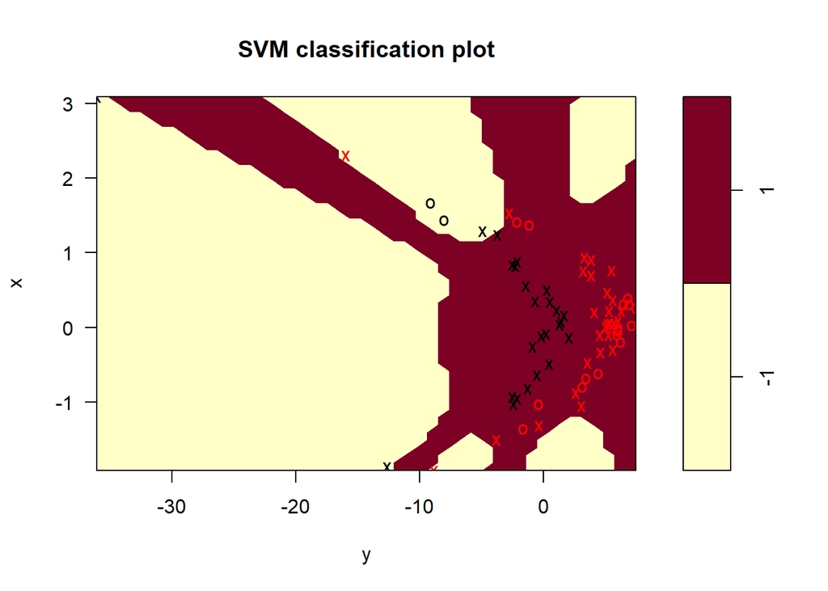

```r
set.seed(500)
svm.poly = svm(z~., data=datos.train, kernel="polynomial", cost=10, degree=11)
plot(svm.poly, datos.train)
```

```r
prediccion = predict(svm.poly, datos.train)
table(prediccion , real = datos.train$z)
```

```
##           real
## prediccion -1  1
##         -1  5  0
##         1  22 43
```

```r
train.error = round(mean(prediccion != datos.train$z)*100,3)

paste("Para un Kernel Polinomial de grado 11 el train error es del", train.error, "%")
```

```
## [1] "Para un Kernel Polinomial de grado 11 el train error es del 31.429 %"
```

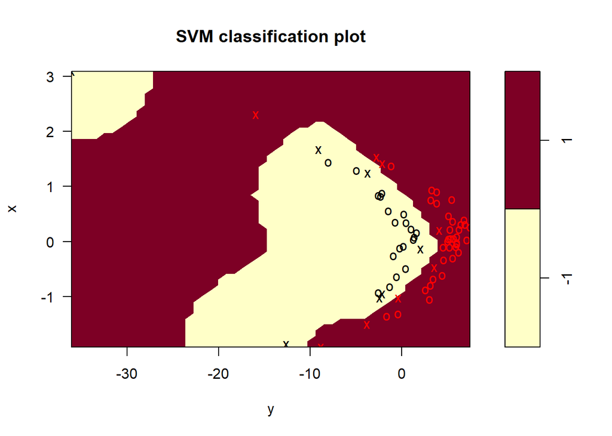

```r
set.seed(600)
svm.radial = svm(z~., data=datos.train, kernel="radial", gamma=1, cost=10)
plot(svm.radial, datos.train)
```

```r
prediccion = predict(svm.radial, datos.train)
table(prediccion , real = datos.train$z)
```

```
##           real
## prediccion -1  1
##         -1 27  0
##         1   0 43
```

```r
train.error = round(mean(prediccion != datos.train$z)*100,3)

paste("Para un Kernel Radial el train error es del", train.error, "%")
```

```
## [1] "Para un Kernel Radial el train error es del 0 %"
```

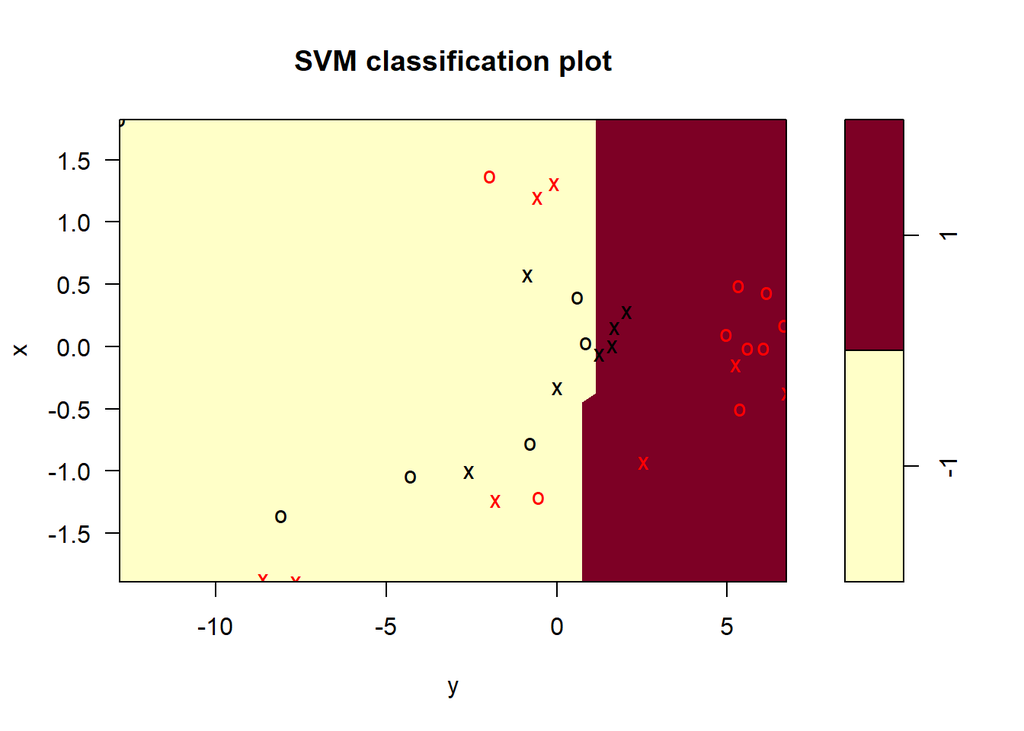

```r
plot(svm.linear, datos.test)
```

```r
prediccion = predict(svm.linear, datos.test)
table(prediccion , real = datos.test$z)
```

```
##           real
## prediccion -1  1
##         -1  8  7
##         1   5 10
```

```r
test.error = round(mean(prediccion != datos.test$z)*100,3)

paste("Para un Kernel Lineal el test error es del", test.error, "%")
```

```
## [1] "Para un Kernel Lineal el test error es del 40 %"
```

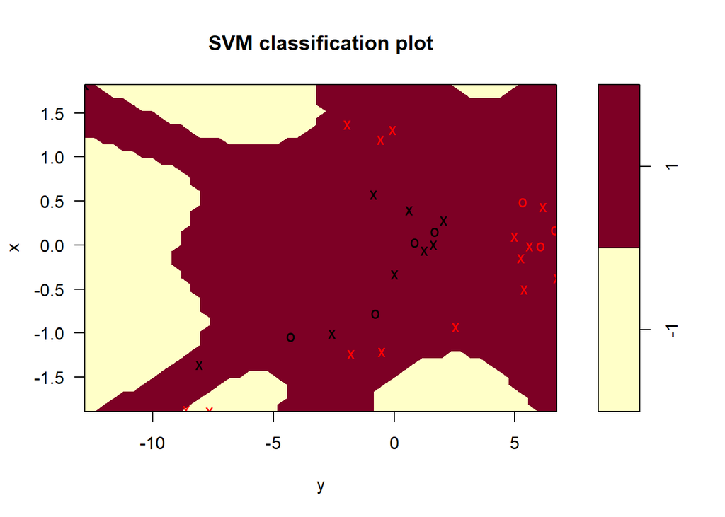

```r
plot(svm.poly, datos.test)
```

```r
prediccion = predict(svm.poly, datos.test)
table(prediccion , real = datos.test$z)
```

```
##           real
## prediccion -1  1
##         -1  0  2
##         1  13 15
```

```r
test.error = round(mean(prediccion != datos.test$z)*100,3)

paste("Para un Kernel Polinomial el test error es del", test.error, "%")
```

```
## [1] "Para un Kernel Polinomial el test error es del 50 %"
```

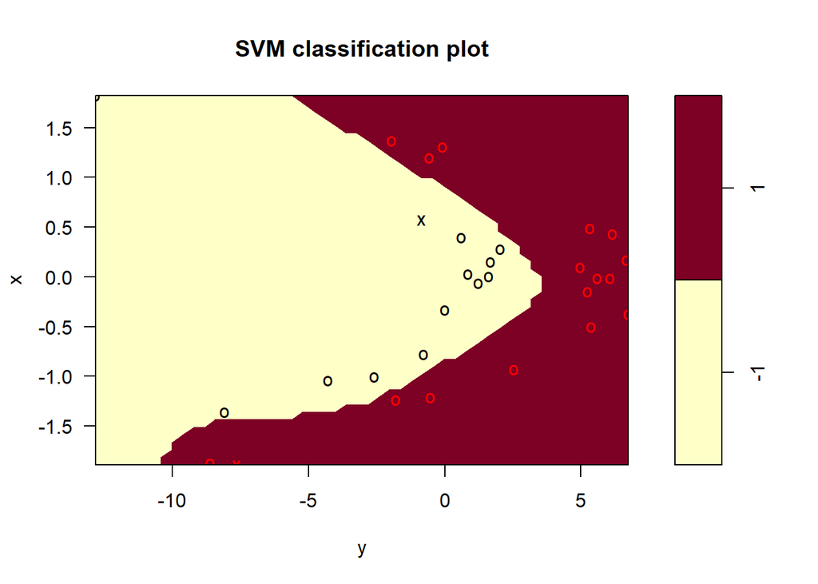

```r
plot(svm.radial, datos.test)
```

```r
prediccion = predict(svm.radial, datos.test)
table(prediccion , real = datos.test$z)
```

```
##           real
## prediccion -1  1
##         -1 12  0
##         1   1 17
```

```r
test.error = round(mean(prediccion != datos.test$z)*100,3)

paste("Para un Kernel Radial el test error es del", test.error, "%")
```

```
## [1] "Para un Kernel Radial el test error es del 3.333 %"
```

El mejor modelo de SVM para este conjunto de datos es el que se basa en un **kernel radial.** Para los datos de entrenamiento tiene un error del **0%** mientras que para los datos de prueba su test error es de tan solo el **3.3%** ya que solo clasifica mal una sola observación. El modelo de SVM con kernel lineal presenta mejor rendimiento con respecto al kernel polinomial, ya que este ultimo no se ajusta muy bien a los datos aun cuando se usa un alto grado para el polinomio.

## Ejercicio 5

We have seen that we can fit an SVM with a non-linear kernel in order to perform classification using a non-linear decision boundary.We will now see that we can also obtain a non-linear decision boundary by performing logistic regression using non-linear transformations of the features.

### (a)

```r
set.seed(700)
x1 = runif(500) - 0.5
x2 = runif(500) - 0.5
y = 1*(x1^2 - x2^2 > 0)
```

### (b)

Plot the observations, colored according to their class labels. Your plot should display X1 on the x-axis, and X2 on the yaxis.

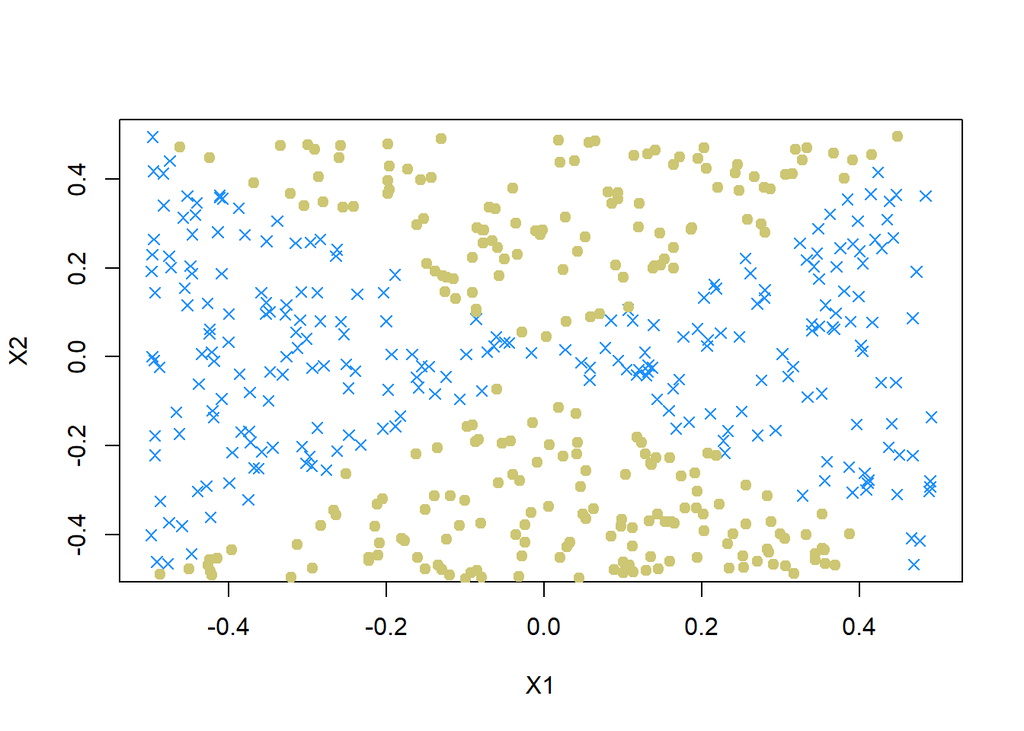

```r
plot(x1[y == 1], x2[y == 1], col = "dodgerblue1", xlab = "X1", ylab = "X2", pch = 4)
points(x1[y == 0], x2[y == 0], col = "khaki3", pch = 19)
```

### (c)

Fit a logistic regression model to the data, using X1 and X2 as predictors.

```r
datos = data.frame(x1 = x1, x2 = x2, y = y)
lg.fit = glm(y ~ ., data = datos, family = binomial)
summary(lg.fit)
```

```
##
## Call:
## glm(formula = y ~ ., family = binomial, data = datos)
##
## Deviance Residuals:
##     Min       1Q   Median       3Q      Max
## -1.4992  -1.1451  -0.9153   1.1678   1.5114
##
## Coefficients:
##             Estimate Std. Error z value Pr(>|z|)
## (Intercept) -0.01207    0.09101  -0.133  0.89447
## x1          -0.78532    0.31973  -2.456  0.01404 *
## x2           0.80701    0.30662   2.632  0.00849 **
## ---
## Signif. codes:  0 '***' 0.001 '**' 0.01 '*' 0.05 '.' 0.1 ' ' 1
##
## (Dispersion parameter for binomial family taken to be 1)
##
##     Null deviance: 693.08  on 499  degrees of freedom
## Residual deviance: 679.79  on 497  degrees of freedom
## AIC: 685.79
##
## Number of Fisher Scoring iterations: 4
```

### (d)

Apply this model to the training data in order to obtain a predicted class label for each training observation. Plot the observations, colored according to the predicted class labels. The decision boundary should be linear.

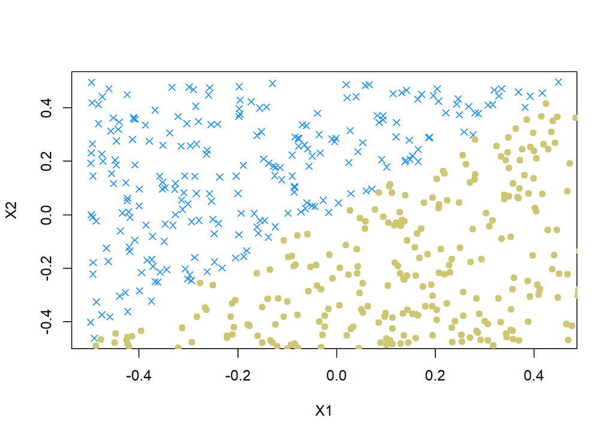

```r
lg.probs = predict(lg.fit, newdata = datos, type = "response")
lg.pred = ifelse(lg.probs > 0.5, 1, 0)
datos.pos = datos[lg.pred == 1, ]
datos.neg = datos[lg.pred == 0, ]
plot(datos.pos$x1, datos.pos$x2, col = "dodgerblue1", xlab = "X1", ylab = "X2", pch = 4)
points(datos.neg$x1, datos.neg$x2, col = "khaki3", pch = 19)
```

Con este modelo de regresión logística se ve una clara diferenciación entre las dos clases. Dicha diferenciación puede hacerse imaginando una línea recta que separe los colores, por lo tanto se puede hablar de un límite línea para este conjunto de datos.

### (e)

Now fit a logistic regression model to the data using non-linear functions of X1 and X2 as predictors (e.g. X21 , X1×X2, log(X2), and so forth).

```r
lg.nolineal.fit = glm(y ~ poly(x1, 3) + poly(x2, 4) + I(x1*x2) , data = datos, family = binomial)
summary(lg.nolineal.fit)
```

```
##
## Call:
## glm(formula = y ~ poly(x1, 3) + poly(x2, 4) + I(x1 * x2), family = binomial,
##     data = datos)
##
## Deviance Residuals:
##        Min          1Q      Median          3Q         Max
## -1.691e-03  -2.000e-08  -2.000e-08   2.000e-08   1.737e-03
##
## Coefficients:
##               Estimate Std. Error z value Pr(>|z|)
## (Intercept)    -205.85    6995.40  -0.029    0.977
## poly(x1, 3)1  -5778.89  160829.94  -0.036    0.971
## poly(x1, 3)2  35720.97  935182.14   0.038    0.970
## poly(x1, 3)3    -38.29   50311.09  -0.001    0.999
## poly(x2, 4)1   6158.04  180215.03   0.034    0.973
## poly(x2, 4)2 -37756.47  991094.82  -0.038    0.970
## poly(x2, 4)3   -356.07   69868.90  -0.005    0.996
## poly(x2, 4)4    797.77  114972.56   0.007    0.994
## I(x1 * x2)      -98.09   35977.45  -0.003    0.998
##
## (Dispersion parameter for binomial family taken to be 1)
##
##     Null deviance: 6.9308e+02  on 499  degrees of freedom
## Residual deviance: 6.3377e-06  on 491  degrees of freedom
## AIC: 18
##
## Number of Fisher Scoring iterations: 25
```

### (f)

Apply this model to the training data in order to obtain a predicted class label for each training observation. Plot the observations, colored according to the predicted class labels. The decision boundary should be obviously non-linear. If it is not, then repeat (a)-(e) until you come up with an example in which the predicted class labels are obviously non-linear.

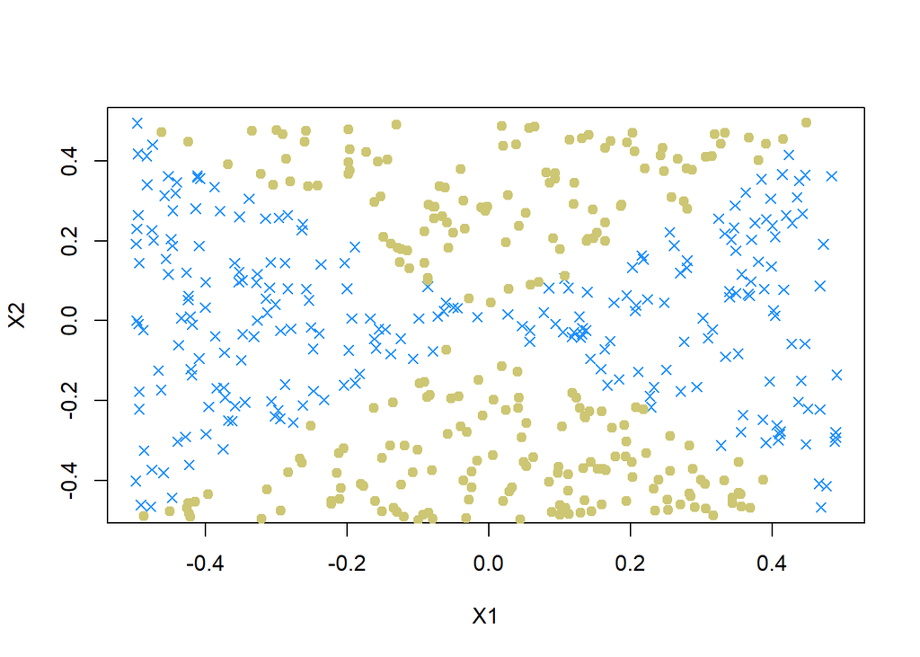

```r
lg.nolineal.probs = predict(lg.nolineal.fit, datos, type = "response")
lg.nolineal.pred = ifelse(lg.nolineal.probs > 0.5, 1, 0)
datos.pos = datos[lg.nolineal.pred == 1, ]
datos.neg = datos[lg.nolineal.pred == 0, ]
plot(datos.pos$x1, datos.pos$x2, col = "dodgerblue1", xlab = "X1", ylab = "X2", pch = 4)
points(datos.neg$x1, datos.neg$x2, col = "khaki3", pch = 19)
```

Con este nuevo modelo de regresión logística no lineal ya no podemos hablar de un límite lineal, porque no se puede imaginar una línea recta que haga una división completa de las dos clases, por tanto se habla de un límite no lineal.